# IE582 - Homework 3

Ufuk Üstündağ

1 January 2021

##Installing Necessary Packages

```r
library(readxl)
library(data.table)
library(glmnet)
```

```r
library(ggplot2)
```

## Inserting Data

```r
datapath = 'C:/Users/ufuk9/Desktop/Electricity_Counsumption_Data.xlsx'
data = read_excel(datapath)

data_electricity = as.data.frame(data)
str(data_electricity)
```

```
## 'data.frame':    43128 obs. of  3 variables:
##  $ Tarih                : chr  "01.01.2016" "01.01.2016" "01.01.2016" "01.01.2016" ...
##  $ Saat                 : POSIXct, format: "1899-12-31 00:00:00" "1899-12-31 01:00:00" ...
##  $ Tuketim Miktari (MWh): num  26277 24992 23533 22465 22003 ...
```

```r
data_electricity[which(data_electricity$`Tuketim Miktari (MWh)` == 0),1]
```

```
## [1] "27.03.2016"
```

```r
data_electricity <- data_electricity[which(data_electricity$Tarih != "27.03.2016"),]
data_electricity <- data_electricity[which(data_electricity$Tarih != "26.03.2016"),]
data_electricity <- data_electricity[which(data_electricity$Tarih != "25.03.2016"),]
data_electricity <- data_electricity[which(data_electricity$Tarih != "24.03.2016"),]
data_electricity <- data_electricity[which(data_electricity$Tarih != "23.03.2016"),]
data_electricity <- data_electricity[which(data_electricity$Tarih != "22.03.2016"),]
data_electricity <- data_electricity[which(data_electricity$Tarih != "21.03.2016"),]
```

A whole week is removed from the data due to the biased values caused by the daylight savings program.

## Creating Long Format

```r
Date <- data_electricity$Tarih

Hour <- vector()
for(i in 1:length(Date)){Hour[i] <- (i-1)%%24}

Consumption <- data_electricity$`Tuketim Miktari (MWh)`

lag_48 <- c(rep(0,48), Consumption[1:(length(Consumption)-48)])
lag_168 <- c(rep(0,168), Consumption[1:(length(Consumption)-168)])

long_format <- data.frame(Date, Hour, lag_48, lag_168, Consumption)
str(long_format)
```

```
## 'data.frame':    42960 obs. of  5 variables:
##  $ Date       : chr  "01.01.2016" "01.01.2016" "01.01.2016" "01.01.2016" ...
##  $ Hour       : num  0 1 2 3 4 5 6 7 8 9 ...
##  $ lag_48     : num  0 0 0 0 0 0 0 0 0 0 ...
##  $ lag_168    : num  0 0 0 0 0 0 0 0 0 0 ...
##  $ Consumption: num  26277 24992 23533 22465 22003 ...
```

## MAPE Function

```r
mape <- function(prediction, target)
{
  ape <- (abs((prediction-target)/target))*100
  print('Performance Summary: Absolute Percentage Errors')
  print(summary(ape))
  return(ape)
}
```

# PART A

```r
#MAPE for lag_48
naive48 <- mape(long_format$lag_48[42385:nrow(long_format)], long_format$Consumption[42385:nrow(long_format)])
```

```
## [1] "Performance Summary: Absolute Percentage Errors"
##     Min.  1st Qu.   Median     Mean  3rd Qu.     Max.
##  0.00955  1.57219  5.63828  8.16504 10.25037 43.77075
```

```r
#MAPE for lag_168
naive168 <- mape(long_format$lag_168[42385:nrow(long_format)], long_format$Consumption[42385:nrow(long_format)])
```

```
## [1] "Performance Summary: Absolute Percentage Errors"
##      Min.   1st Qu.    Median      Mean   3rd Qu.      Max.
##  0.008521  1.239858  2.164683  2.779969  3.443539 14.297794
```

When the naive models are compared, it is noticed that lag_168 model performs a lot better than lag_48. This indicates that the electricity consumption data has a stronger weekly seasonality than daily seasonality.

# PART B

```r
lin_reg_model <- lm(Consumption~., data=long_format[169:42384,3:5])
summary(lin_reg_model)
```

```
##
## Call:
## lm(formula = Consumption ~ ., data = long_format[169:42384, 3:5])
##
## Residuals:
##      Min       1Q   Median       3Q      Max
## -17132.1   -988.8     -2.0   1021.6  16096.9
##
## Coefficients:
##              Estimate Std. Error t value Pr(>|t|)
## (Intercept) 1.571e+03  8.359e+01   18.80   <2e-16 ***
## lag_48      3.086e-01  3.096e-03   99.69   <2e-16 ***
## lag_168     6.436e-01  3.094e-03  208.02   <2e-16 ***
## ---
## Signif. codes:  0 '***' 0.001 '**' 0.01 '*' 0.05 '.' 0.1 ' ' 1
##
## Residual standard error: 2391 on 42213 degrees of freedom
## Multiple R-squared:  0.7751, Adjusted R-squared:  0.7751
## F-statistic: 7.276e+04 on 2 and 42213 DF,  p-value: < 2.2e-16
```

```r
lm_prediction <- predict(lin_reg_model, long_format[42385:nrow(long_format),3:5])
linreg_whole <- mape(lm_prediction, long_format$Consumption[42385:nrow(long_format)])
```

```
## [1] "Performance Summary: Absolute Percentage Errors"
##      Min.   1st Qu.    Median      Mean   3rd Qu.      Max.
##  0.002533  1.578096  2.788475  3.756859  4.814336 16.595897
```

# PART C

```r
lin_reg_hour <- function(h)
{
  hour <- long_format[long_format$Hour==h,]
  lin_reg <- lm(Consumption~., data=hour[8:1759,3:5])
  print(summary(lin_reg))

  lm_prediction <- predict(lin_reg, hour[1760:nrow(hour),3:5])
  ape <- mape(lm_prediction, hour$Consumption[1760:nrow(hour)])
  return(ape)
}

linreg0 <- lin_reg_hour(0)
```

```
##
## Call:
## lm(formula = Consumption ~ ., data = hour[8:1759, 3:5])
##
## Residuals:
##     Min      1Q  Median      3Q     Max
## -9163.5  -801.4    42.6   890.0  6401.0
##
## Coefficients:
##              Estimate Std. Error t value Pr(>|t|)
## (Intercept) 2.208e+03  4.337e+02   5.092 3.93e-07 ***
## lag_48      4.871e-01  1.690e-02  28.822  < 2e-16 ***
## lag_168     4.421e-01  1.687e-02  26.211  < 2e-16 ***
## ---
## Signif. codes:  0 '***' 0.001 '**' 0.01 '*' 0.05 '.' 0.1 ' ' 1
##
## Residual standard error: 1594 on 1749 degrees of freedom
## Multiple R-squared:  0.7196, Adjusted R-squared:  0.7193
## F-statistic:  2244 on 2 and 1749 DF,  p-value: < 2.2e-16
##
## [1] "Performance Summary: Absolute Percentage Errors"
##    Min. 1st Qu.  Median    Mean 3rd Qu.    Max.
##  0.9108  1.8986  3.1364  3.2637  4.6175  6.7737
```

```r
linreg1 <- lin_reg_hour(1)
```

```
##
## Call:
## lm(formula = Consumption ~ ., data = hour[8:1759, 3:5])
##
## Residuals:
##     Min      1Q  Median      3Q     Max
## -9386.4  -775.9    78.0   843.0  6447.1
##
## Coefficients:
##              Estimate Std. Error t value Pr(>|t|)
## (Intercept) 2.137e+03  4.152e+02   5.146 2.95e-07 ***
## lag_48      4.922e-01  1.691e-02  29.102  < 2e-16 ***
## lag_168     4.356e-01  1.688e-02  25.815  < 2e-16 ***
## ---
## Signif. codes:  0 '***' 0.001 '**' 0.01 '*' 0.05 '.' 0.1 ' ' 1
##
## Residual standard error: 1564 on 1749 degrees of freedom
## Multiple R-squared:  0.7156, Adjusted R-squared:  0.7153
## F-statistic:  2201 on 2 and 1749 DF,  p-value: < 2.2e-16
##
## [1] "Performance Summary: Absolute Percentage Errors"
##    Min. 1st Qu.  Median    Mean 3rd Qu.    Max.
##  0.1601  2.0236  3.0280  3.2839  4.5901  7.4938
```

```r
linreg2 <- lin_reg_hour(2)
```

```
##
## Call:
## lm(formula = Consumption ~ ., data = hour[8:1759, 3:5])
##
## Residuals:
##     Min      1Q  Median      3Q     Max
## -9158.2  -809.6    67.5   863.7  6273.8
##
## Coefficients:
##              Estimate Std. Error t value Pr(>|t|)
## (Intercept) 2.212e+03  4.120e+02   5.368    9e-08 ***
## lag_48      4.972e-01  1.703e-02  29.198   <2e-16 ***
## lag_168     4.252e-01  1.698e-02  25.036   <2e-16 ***
## ---
## Signif. codes:  0 '***' 0.001 '**' 0.01 '*' 0.05 '.' 0.1 ' ' 1
##
## Residual standard error: 1549 on 1749 degrees of freedom
## Multiple R-squared:  0.7007, Adjusted R-squared:  0.7004
## F-statistic:  2047 on 2 and 1749 DF,  p-value: < 2.2e-16
##
## [1] "Performance Summary: Absolute Percentage Errors"
##    Min. 1st Qu.  Median    Mean 3rd Qu.    Max.
##  0.2827  2.1537  3.5217  3.4195  4.5493  6.6624
```

```r
linreg3 <- lin_reg_hour(3)
```

```
##
## Call:
## lm(formula = Consumption ~ ., data = hour[8:1759, 3:5])
##
## Residuals:
##     Min      1Q  Median      3Q     Max
## -8869.9  -817.9    67.6   877.2  6268.0
##
## Coefficients:
##              Estimate Std. Error t value Pr(>|t|)
## (Intercept) 2.243e+03  4.096e+02   5.476 4.97e-08 ***
## lag_48      4.928e-01  1.708e-02  28.844  < 2e-16 ***
## lag_168     4.265e-01  1.703e-02  25.038  < 2e-16 ***
## ---
## Signif. codes:  0 '***' 0.001 '**' 0.01 '*' 0.05 '.' 0.1 ' ' 1
##
## Residual standard error: 1524 on 1749 degrees of freedom
## Multiple R-squared:  0.6908, Adjusted R-squared:  0.6904
## F-statistic:  1954 on 2 and 1749 DF,  p-value: < 2.2e-16
##
## [1] "Performance Summary: Absolute Percentage Errors"
##    Min. 1st Qu.  Median    Mean 3rd Qu.    Max.
##  0.2128  1.9415  2.6503  3.2030  4.3020  6.5757
```

```r
linreg4 <- lin_reg_hour(4)
```

```
##
## Call:
## lm(formula = Consumption ~ ., data = hour[8:1759, 3:5])
##
## Residuals:
##     Min      1Q  Median      3Q     Max
## -7887.1  -804.6    41.6   868.0  6284.4
##
## Coefficients:
##              Estimate Std. Error t value Pr(>|t|)
## (Intercept) 2.214e+03  4.116e+02    5.38 8.47e-08 ***
## lag_48      4.747e-01  1.701e-02   27.92  < 2e-16 ***
## lag_168     4.446e-01  1.696e-02   26.22  < 2e-16 ***
## ---
## Signif. codes:  0 '***' 0.001 '**' 0.01 '*' 0.05 '.' 0.1 ' ' 1
##
## Residual standard error: 1498 on 1749 degrees of freedom
## Multiple R-squared:  0.6832, Adjusted R-squared:  0.6828
## F-statistic:  1886 on 2 and 1749 DF,  p-value: < 2.2e-16
##
## [1] "Performance Summary: Absolute Percentage Errors"
##    Min. 1st Qu.  Median    Mean 3rd Qu.    Max.
## 0.06635 1.95433 3.14070 3.18297 4.16485 6.42165
```

```r
linreg5 <- lin_reg_hour(5)
```

```
##
## Call:
## lm(formula = Consumption ~ ., data = hour[8:1759, 3:5])
##
## Residuals:
##     Min      1Q  Median      3Q     Max
## -7438.5  -783.4    33.3   841.3  6377.8
##
## Coefficients:
##              Estimate Std. Error t value Pr(>|t|)
## (Intercept) 2.235e+03  4.209e+02   5.311 1.23e-07 ***
## lag_48      4.397e-01  1.693e-02  25.973  < 2e-16 ***
## lag_168     4.782e-01  1.689e-02  28.316  < 2e-16 ***
## ---
## Signif. codes:  0 '***' 0.001 '**' 0.01 '*' 0.05 '.' 0.1 ' ' 1
##
## Residual standard error: 1488 on 1749 degrees of freedom
## Multiple R-squared:  0.6696, Adjusted R-squared:  0.6692
## F-statistic:  1772 on 2 and 1749 DF,  p-value: < 2.2e-16
##
## [1] "Performance Summary: Absolute Percentage Errors"
##    Min. 1st Qu.  Median    Mean 3rd Qu.    Max.
##  0.2771  1.9870  2.8525  3.1876  4.6314  6.3251
```

```r
linreg6 <- lin_reg_hour(6)
```

```
##
## Call:
## lm(formula = Consumption ~ ., data = hour[8:1759, 3:5])
##
## Residuals:
##     Min      1Q  Median      3Q     Max
## -7427.9  -730.7    37.9   850.0  7046.7
##
## Coefficients:
##              Estimate Std. Error t value Pr(>|t|)
## (Intercept) 2.139e+03  4.264e+02   5.016 5.81e-07 ***
## lag_48      3.758e-01  1.655e-02  22.701  < 2e-16 ***
## lag_168     5.460e-01  1.652e-02  33.046  < 2e-16 ***
## ---
## Signif. codes:  0 '***' 0.001 '**' 0.01 '*' 0.05 '.' 0.1 ' ' 1
##
## Residual standard error: 1568 on 1749 degrees of freedom
## Multiple R-squared:  0.6693, Adjusted R-squared:  0.6689
## F-statistic:  1770 on 2 and 1749 DF,  p-value: < 2.2e-16
##
## [1] "Performance Summary: Absolute Percentage Errors"
##    Min. 1st Qu.  Median    Mean 3rd Qu.    Max.
##  0.1487  1.2064  2.8691  3.1483  5.1657  6.7580
```

```r
linreg7 <- lin_reg_hour(7)
```

```
##
## Call:
## lm(formula = Consumption ~ ., data = hour[8:1759, 3:5])
##
## Residuals:
##     Min      1Q  Median      3Q     Max
## -8815.2  -807.4    65.5   933.0  8959.0
##
## Coefficients:
##              Estimate Std. Error t value Pr(>|t|)
## (Intercept) 2.319e+03  4.743e+02   4.889 1.11e-06 ***
## lag_48      2.668e-01  1.573e-02  16.963  < 2e-16 ***
## lag_168     6.521e-01  1.569e-02  41.552  < 2e-16 ***
## ---
## Signif. codes:  0 '***' 0.001 '**' 0.01 '*' 0.05 '.' 0.1 ' ' 1
##
## Residual standard error: 1917 on 1749 degrees of freedom
## Multiple R-squared:  0.6536, Adjusted R-squared:  0.6532
## F-statistic:  1650 on 2 and 1749 DF,  p-value: < 2.2e-16
##
## [1] "Performance Summary: Absolute Percentage Errors"
##    Min. 1st Qu.  Median    Mean 3rd Qu.    Max.
##  0.3471  1.8379  3.5988  3.7774  5.0005  9.2563
```

```r
linreg8 <- lin_reg_hour(8)
```

```
##
## Call:
## lm(formula = Consumption ~ ., data = hour[8:1759, 3:5])
##
## Residuals:
##      Min       1Q   Median       3Q      Max
## -13439.7  -1021.0    131.5   1185.1  13080.7
##
## Coefficients:
##              Estimate Std. Error t value Pr(>|t|)
## (Intercept) 3.241e+03  6.069e+02    5.34 1.05e-07 ***
## lag_48      1.741e-01  1.523e-02   11.43  < 2e-16 ***
## lag_168     7.249e-01  1.521e-02   47.67  < 2e-16 ***
## ---
## Signif. codes:  0 '***' 0.001 '**' 0.01 '*' 0.05 '.' 0.1 ' ' 1
##
## Residual standard error: 2713 on 1749 degrees of freedom
## Multiple R-squared:  0.6171, Adjusted R-squared:  0.6167
## F-statistic:  1410 on 2 and 1749 DF,  p-value: < 2.2e-16
##
## [1] "Performance Summary: Absolute Percentage Errors"
##     Min.  1st Qu.   Median     Mean  3rd Qu.     Max.
##  0.06138  2.66680  3.94190  4.67584  6.72608 12.90594
```

```r
linreg9 <- lin_reg_hour(9)
```

```
##
## Call:
## lm(formula = Consumption ~ ., data = hour[8:1759, 3:5])
##
## Residuals:
##      Min       1Q   Median       3Q      Max
## -15679.5  -1297.3    118.6   1351.8  15014.9
##
## Coefficients:
##              Estimate Std. Error t value Pr(>|t|)
## (Intercept) 3.603e+03  6.576e+02   5.478 4.92e-08 ***
## lag_48      1.747e-01  1.539e-02  11.358  < 2e-16 ***
## lag_168     7.201e-01  1.537e-02  46.840  < 2e-16 ***
## ---
## Signif. codes:  0 '***' 0.001 '**' 0.01 '*' 0.05 '.' 0.1 ' ' 1
##
## Residual standard error: 3064 on 1749 degrees of freedom
## Multiple R-squared:  0.6084, Adjusted R-squared:  0.608
## F-statistic:  1359 on 2 and 1749 DF,  p-value: < 2.2e-16
##
## [1] "Performance Summary: Absolute Percentage Errors"
##    Min. 1st Qu.  Median    Mean 3rd Qu.    Max.
##  0.2447  2.5305  5.0982  5.4887  8.3229 15.7676
```

```r
linreg10 <- lin_reg_hour(10)
```

```
##
## Call:
## lm(formula = Consumption ~ ., data = hour[8:1759, 3:5])
##
## Residuals:
##      Min       1Q   Median       3Q      Max
## -16524.2  -1358.8     96.9   1460.8  15548.9
##
## Coefficients:
##              Estimate Std. Error t value Pr(>|t|)
## (Intercept) 3.747e+03  6.697e+02   5.595 2.55e-08 ***
## lag_48      2.066e-01  1.588e-02  13.007  < 2e-16 ***
## lag_168     6.864e-01  1.588e-02  43.232  < 2e-16 ***
## ---
## Signif. codes:  0 '***' 0.001 '**' 0.01 '*' 0.05 '.' 0.1 ' ' 1
##
## Residual standard error: 3084 on 1749 degrees of freedom
## Multiple R-squared:  0.5948, Adjusted R-squared:  0.5944
## F-statistic:  1284 on 2 and 1749 DF,  p-value: < 2.2e-16
##
## [1] "Performance Summary: Absolute Percentage Errors"
##    Min. 1st Qu.  Median    Mean 3rd Qu.    Max.
##  0.7179  3.1412  5.5444  6.0904  8.5552 14.2958
```

```r
linreg11 <- lin_reg_hour(11)
```

```
##
## Call:
## lm(formula = Consumption ~ ., data = hour[8:1759, 3:5])
##
## Residuals:
##      Min       1Q   Median       3Q      Max
## -17063.7  -1439.1     87.9   1526.5  15679.8
##
## Coefficients:
##              Estimate Std. Error t value Pr(>|t|)
## (Intercept) 3.966e+03  6.869e+02   5.774 9.15e-09 ***
## lag_48      2.252e-01  1.624e-02  13.866  < 2e-16 ***
## lag_168     6.632e-01  1.624e-02  40.827  < 2e-16 ***
## ---
## Signif. codes:  0 '***' 0.001 '**' 0.01 '*' 0.05 '.' 0.1 ' ' 1
##
## Residual standard error: 3133 on 1749 degrees of freedom
## Multiple R-squared:  0.5812, Adjusted R-squared:  0.5807
## F-statistic:  1214 on 2 and 1749 DF,  p-value: < 2.2e-16
##
## [1] "Performance Summary: Absolute Percentage Errors"
##     Min.  1st Qu.   Median     Mean  3rd Qu.     Max.
##  0.06143  3.05454  5.64322  6.27568  8.15349 14.78876
```

```r
linreg12 <- lin_reg_hour(12)
```

```
##
## Call:
## lm(formula = Consumption ~ ., data = hour[8:1759, 3:5])
##
## Residuals:
##    Min     1Q Median     3Q    Max
## -15478  -1435     49   1514  14608
##
## Coefficients:
##              Estimate Std. Error t value Pr(>|t|)
## (Intercept) 3.671e+03  6.340e+02   5.791  8.3e-09 ***
## lag_48      2.802e-01  1.668e-02  16.795  < 2e-16 ***
## lag_168     6.129e-01  1.669e-02  36.728  < 2e-16 ***
## ---
## Signif. codes:  0 '***' 0.001 '**' 0.01 '*' 0.05 '.' 0.1 ' ' 1
##
## Residual standard error: 2876 on 1749 degrees of freedom
## Multiple R-squared:  0.5907, Adjusted R-squared:  0.5902
## F-statistic:  1262 on 2 and 1749 DF,  p-value: < 2.2e-16
##
## [1] "Performance Summary: Absolute Percentage Errors"
##    Min. 1st Qu.  Median    Mean 3rd Qu.    Max.
##  0.2715  3.0153  6.0018  6.5445  9.0367 15.8728
```

```r
linreg13 <- lin_reg_hour(13)
```

```
##
## Call:
## lm(formula = Consumption ~ ., data = hour[8:1759, 3:5])
##
## Residuals:
##      Min       1Q   Median       3Q      Max
## -15515.0  -1463.0    -53.7   1526.3  14800.8
##
## Coefficients:
##              Estimate Std. Error t value Pr(>|t|)
## (Intercept) 3.815e+03  6.445e+02    5.92 3.87e-09 ***
## lag_48      3.037e-01  1.696e-02   17.91  < 2e-16 ***
## lag_168     5.865e-01  1.696e-02   34.59  < 2e-16 ***
## ---
## Signif. codes:  0 '***' 0.001 '**' 0.01 '*' 0.05 '.' 0.1 ' ' 1
##
## Residual standard error: 2947 on 1749 degrees of freedom
## Multiple R-squared:  0.5824, Adjusted R-squared:  0.5819
## F-statistic:  1220 on 2 and 1749 DF,  p-value: < 2.2e-16
##
## [1] "Performance Summary: Absolute Percentage Errors"
##    Min. 1st Qu.  Median    Mean 3rd Qu.    Max.
##  0.7723  2.8759  5.5035  6.6855  9.1728 16.5712
```

```r
linreg14 <- lin_reg_hour(14)
```

```
##
## Call:
## lm(formula = Consumption ~ ., data = hour[8:1759, 3:5])
##
## Residuals:
##      Min       1Q   Median       3Q      Max
## -16080.3  -1560.7    -15.8   1659.5  15593.0
##
## Coefficients:
##              Estimate Std. Error t value Pr(>|t|)
## (Intercept) 4.078e+03  6.867e+02   5.938 3.48e-09 ***
## lag_48      2.598e-01  1.670e-02  15.562  < 2e-16 ***
## lag_168     6.252e-01  1.669e-02  37.447  < 2e-16 ***
## ---
## Signif. codes:  0 '***' 0.001 '**' 0.01 '*' 0.05 '.' 0.1 ' ' 1
##
## Residual standard error: 3167 on 1749 degrees of freedom
## Multiple R-squared:  0.5681, Adjusted R-squared:  0.5676
## F-statistic:  1150 on 2 and 1749 DF,  p-value: < 2.2e-16
##
## [1] "Performance Summary: Absolute Percentage Errors"
##    Min. 1st Qu.  Median    Mean 3rd Qu.    Max.
##   0.285   3.238   4.949   6.483   9.267  15.238
```

```r
linreg15 <- lin_reg_hour(15)
```

```
##
## Call:
## lm(formula = Consumption ~ ., data = hour[8:1759, 3:5])
##
## Residuals:
##      Min       1Q   Median       3Q      Max
## -15892.0  -1542.1     29.8   1579.7  15340.9
##
## Coefficients:
##              Estimate Std. Error t value Pr(>|t|)
## (Intercept) 3.963e+03  6.800e+02   5.828 6.67e-09 ***
## lag_48      2.565e-01  1.658e-02  15.472  < 2e-16 ***
## lag_168     6.315e-01  1.657e-02  38.101  < 2e-16 ***
## ---
## Signif. codes:  0 '***' 0.001 '**' 0.01 '*' 0.05 '.' 0.1 ' ' 1
##
## Residual standard error: 3127 on 1749 degrees of freedom
## Multiple R-squared:  0.5744, Adjusted R-squared:  0.5739
## F-statistic:  1180 on 2 and 1749 DF,  p-value: < 2.2e-16
##
## [1] "Performance Summary: Absolute Percentage Errors"
##    Min. 1st Qu.  Median    Mean 3rd Qu.    Max.
##  0.8032  2.8361  5.4487  6.0845  8.8966 13.1972
```

```r
linreg16 <- lin_reg_hour(16)
```

```
##
## Call:
## lm(formula = Consumption ~ ., data = hour[8:1759, 3:5])
##
## Residuals:
##      Min       1Q   Median       3Q      Max
## -15323.9  -1481.0     40.9   1516.6  15023.0
##
## Coefficients:
##              Estimate Std. Error t value Pr(>|t|)
## (Intercept) 3.830e+03  6.758e+02   5.667 1.69e-08 ***
## lag_48      2.473e-01  1.636e-02  15.116  < 2e-16 ***
## lag_168     6.451e-01  1.636e-02  39.438  < 2e-16 ***
## ---
## Signif. codes:  0 '***' 0.001 '**' 0.01 '*' 0.05 '.' 0.1 ' ' 1
##
## Residual standard error: 3039 on 1749 degrees of freedom
## Multiple R-squared:  0.5847, Adjusted R-squared:  0.5843
## F-statistic:  1231 on 2 and 1749 DF,  p-value: < 2.2e-16
##
## [1] "Performance Summary: Absolute Percentage Errors"
##    Min. 1st Qu.  Median    Mean 3rd Qu.    Max.
##  0.4493  2.3224  5.1918  5.1491  7.6364 11.4976
```

```r
linreg17 <- lin_reg_hour(17)
```

```
##
## Call:
## lm(formula = Consumption ~ ., data = hour[8:1759, 3:5])
##
## Residuals:
##      Min       1Q   Median       3Q      Max
## -14126.7  -1333.3     32.8   1379.8  13302.4
##
## Coefficients:
##              Estimate Std. Error t value Pr(>|t|)
## (Intercept) 3.408e+03  6.409e+02   5.317 1.19e-07 ***
## lag_48      2.625e-01  1.615e-02  16.252  < 2e-16 ***
## lag_168     6.422e-01  1.615e-02  39.768  < 2e-16 ***
## ---
## Signif. codes:  0 '***' 0.001 '**' 0.01 '*' 0.05 '.' 0.1 ' ' 1
##
## Residual standard error: 2763 on 1749 degrees of freedom
## Multiple R-squared:  0.6138, Adjusted R-squared:  0.6134
## F-statistic:  1390 on 2 and 1749 DF,  p-value: < 2.2e-16
##
## [1] "Performance Summary: Absolute Percentage Errors"
##    Min. 1st Qu.  Median    Mean 3rd Qu.    Max.
##  0.3607  2.0761  4.2800  4.6126  6.6728 10.8511
```

```r
linreg18 <- lin_reg_hour(18)
```

```
##
## Call:
## lm(formula = Consumption ~ ., data = hour[8:1759, 3:5])
##
## Residuals:
##      Min       1Q   Median       3Q      Max
## -12685.4  -1112.1     70.1   1211.9  10516.6
##
## Coefficients:
##              Estimate Std. Error t value Pr(>|t|)
## (Intercept) 3.036e+03  5.866e+02   5.176 2.53e-07 ***
## lag_48      3.351e-01  1.651e-02  20.297  < 2e-16 ***
## lag_168     5.801e-01  1.650e-02  35.151  < 2e-16 ***
## ---
## Signif. codes:  0 '***' 0.001 '**' 0.01 '*' 0.05 '.' 0.1 ' ' 1
##
## Residual standard error: 2316 on 1749 degrees of freedom
## Multiple R-squared:  0.6476, Adjusted R-squared:  0.6472
## F-statistic:  1607 on 2 and 1749 DF,  p-value: < 2.2e-16
##
## [1] "Performance Summary: Absolute Percentage Errors"
##    Min. 1st Qu.  Median    Mean 3rd Qu.    Max.
##  0.3583  2.2343  3.3821  3.7434  5.1840  8.6344
```

```r
linreg19 <- lin_reg_hour(19)
```

```
##
## Call:
## lm(formula = Consumption ~ ., data = hour[8:1759, 3:5])
##
## Residuals:
##    Min     1Q Median     3Q    Max
## -11665  -1016     54   1082   9170
##
## Coefficients:
##              Estimate Std. Error t value Pr(>|t|)
## (Intercept) 3.177e+03  5.834e+02   5.446 5.88e-08 ***
## lag_48      3.872e-01  1.693e-02  22.868  < 2e-16 ***
## lag_168     5.244e-01  1.692e-02  30.997  < 2e-16 ***
## ---
## Signif. codes:  0 '***' 0.001 '**' 0.01 '*' 0.05 '.' 0.1 ' ' 1
##
## Residual standard error: 2061 on 1749 degrees of freedom
## Multiple R-squared:  0.6457, Adjusted R-squared:  0.6453
## F-statistic:  1594 on 2 and 1749 DF,  p-value: < 2.2e-16
##
## [1] "Performance Summary: Absolute Percentage Errors"
##    Min. 1st Qu.  Median    Mean 3rd Qu.    Max.
##  0.1496  1.9992  3.2561  3.4354  4.6260  7.8134
```

```r
linreg20 <- lin_reg_hour(20)
```

```
##
## Call:
## lm(formula = Consumption ~ ., data = hour[8:1759, 3:5])
##
## Residuals:
##      Min       1Q   Median       3Q      Max
## -10403.4   -990.5     35.6   1059.6   8408.3
##
## Coefficients:
##              Estimate Std. Error t value Pr(>|t|)
## (Intercept) 2.797e+03  5.416e+02   5.164 2.69e-07 ***
## lag_48      4.076e-01  1.680e-02  24.257  < 2e-16 ***
## lag_168     5.144e-01  1.678e-02  30.653  < 2e-16 ***
## ---
## Signif. codes:  0 '***' 0.001 '**' 0.01 '*' 0.05 '.' 0.1 ' ' 1
##
## Residual standard error: 1918 on 1749 degrees of freedom
## Multiple R-squared:  0.6824, Adjusted R-squared:  0.6821
## F-statistic:  1879 on 2 and 1749 DF,  p-value: < 2.2e-16
##
## [1] "Performance Summary: Absolute Percentage Errors"
##    Min. 1st Qu.  Median    Mean 3rd Qu.    Max.
##  0.1194  1.4254  2.9451  3.1631  4.4616  7.7084
```

```r
linreg21 <- lin_reg_hour(21)
```

```
##
## Call:
## lm(formula = Consumption ~ ., data = hour[8:1759, 3:5])
##
## Residuals:
##      Min       1Q   Median       3Q      Max
## -10006.8   -939.1      0.3    995.2   8524.9
##
## Coefficients:
##              Estimate Std. Error t value Pr(>|t|)
## (Intercept) 2.674e+03  5.193e+02    5.15  2.9e-07 ***
## lag_48      4.285e-01  1.686e-02   25.42  < 2e-16 ***
## lag_168     4.955e-01  1.684e-02   29.43  < 2e-16 ***
## ---
## Signif. codes:  0 '***' 0.001 '**' 0.01 '*' 0.05 '.' 0.1 ' ' 1
##
## Residual standard error: 1854 on 1749 degrees of freedom
## Multiple R-squared:  0.6933, Adjusted R-squared:  0.6929
## F-statistic:  1977 on 2 and 1749 DF,  p-value: < 2.2e-16
##
## [1] "Performance Summary: Absolute Percentage Errors"
##    Min. 1st Qu.  Median    Mean 3rd Qu.    Max.
##  0.1074  1.5925  2.6624  3.1646  4.4276  7.5832
```

```r
linreg22 <- lin_reg_hour(22)
```

```
##
## Call:
## lm(formula = Consumption ~ ., data = hour[8:1759, 3:5])
##
## Residuals:
##      Min       1Q   Median       3Q      Max
## -10247.0   -909.8     29.3    994.4   8143.4
##
## Coefficients:
##              Estimate Std. Error t value Pr(>|t|)
## (Intercept) 2.839e+03  5.273e+02   5.383 8.31e-08 ***
## lag_48      4.420e-01  1.706e-02  25.903  < 2e-16 ***
## lag_168     4.757e-01  1.705e-02  27.902  < 2e-16 ***
## ---
## Signif. codes:  0 '***' 0.001 '**' 0.01 '*' 0.05 '.' 0.1 ' ' 1
##
## Residual standard error: 1831 on 1749 degrees of freedom
## Multiple R-squared:  0.6749, Adjusted R-squared:  0.6745
## F-statistic:  1815 on 2 and 1749 DF,  p-value: < 2.2e-16
##
## [1] "Performance Summary: Absolute Percentage Errors"
##    Min. 1st Qu.  Median    Mean 3rd Qu.    Max.
##  0.5942  1.6780  2.9445  3.1647  4.2835  6.9034
```

```r
linreg23 <- lin_reg_hour(23)
```

```
##
## Call:
## lm(formula = Consumption ~ ., data = hour[8:1759, 3:5])
##
## Residuals:
##     Min      1Q  Median      3Q     Max
## -9572.7  -853.5    55.4   920.6  7915.2
##
## Coefficients:
##              Estimate Std. Error t value Pr(>|t|)
## (Intercept) 2.556e+03  4.882e+02   5.235 1.85e-07 ***
## lag_48      4.505e-01  1.699e-02  26.517  < 2e-16 ***
## lag_168     4.722e-01  1.697e-02  27.823  < 2e-16 ***
## ---
## Signif. codes:  0 '***' 0.001 '**' 0.01 '*' 0.05 '.' 0.1 ' ' 1
##
## Residual standard error: 1741 on 1749 degrees of freedom
## Multiple R-squared:  0.692,  Adjusted R-squared:  0.6917
## F-statistic:  1965 on 2 and 1749 DF,  p-value: < 2.2e-16
##
## [1] "Performance Summary: Absolute Percentage Errors"
##    Min. 1st Qu.  Median    Mean 3rd Qu.    Max.
##  0.6136  1.9756  2.8713  3.3847  4.6809  7.4603
```

```r
#Overall performance
perf_linreg_byhour <- c(linreg0, linreg1, linreg2, linreg3, linreg4, linreg5, linreg6, linreg7,
                        linreg8, linreg9, linreg10, linreg11, linreg12, linreg13, linreg14, linreg15,
                        linreg16, linreg17, linreg18, linreg19, linreg20, linreg21, linreg22, linreg23)
print('Performance Summary: Absolute Percentage Errors')
```

```
## [1] "Performance Summary: Absolute Percentage Errors"
```

```r
summary(perf_linreg_byhour)
```

```
##     Min.  1st Qu.   Median     Mean  3rd Qu.     Max.
##  0.06138  2.18669  3.73310  4.35884  5.91848 16.57118
```

When linear regression is applied on the data by two different procedures, in overall MAPE performance, application on the whole data at once gave slightly better performance measures. However, it is noticed that at some hour values, linear regresion on hourly data performs quite exceptional, whereas its performance worsen drastically towards the mid-day hours.

# PART D

## Creating Wide Format

```r
date_wide <- unique(long_format$Date)

lag_2day_hour0 <- long_format[long_format$Hour==0,3]
lag_2day_hour1 <- long_format[long_format$Hour==1,3]
lag_2day_hour2 <- long_format[long_format$Hour==2,3]
lag_2day_hour3 <- long_format[long_format$Hour==3,3]
lag_2day_hour4 <- long_format[long_format$Hour==4,3]
lag_2day_hour5 <- long_format[long_format$Hour==5,3]
lag_2day_hour6 <- long_format[long_format$Hour==6,3]
lag_2day_hour7 <- long_format[long_format$Hour==7,3]
lag_2day_hour8 <- long_format[long_format$Hour==8,3]
lag_2day_hour9 <- long_format[long_format$Hour==9,3]
lag_2day_hour10 <- long_format[long_format$Hour==10,3]
lag_2day_hour11 <- long_format[long_format$Hour==11,3]
lag_2day_hour12 <- long_format[long_format$Hour==12,3]
lag_2day_hour13 <- long_format[long_format$Hour==13,3]
lag_2day_hour14 <- long_format[long_format$Hour==14,3]
lag_2day_hour15 <- long_format[long_format$Hour==15,3]
lag_2day_hour16 <- long_format[long_format$Hour==16,3]
lag_2day_hour17 <- long_format[long_format$Hour==17,3]
lag_2day_hour18 <- long_format[long_format$Hour==18,3]
lag_2day_hour19 <- long_format[long_format$Hour==19,3]
lag_2day_hour20 <- long_format[long_format$Hour==20,3]
lag_2day_hour21 <- long_format[long_format$Hour==21,3]
lag_2day_hour22 <- long_format[long_format$Hour==22,3]
lag_2day_hour23 <- long_format[long_format$Hour==23,3]

lag_7day_hour0 <- long_format[long_format$Hour==0,4]
lag_7day_hour1 <- long_format[long_format$Hour==1,4]
lag_7day_hour2 <- long_format[long_format$Hour==2,4]
lag_7day_hour3 <- long_format[long_format$Hour==3,4]
lag_7day_hour4 <- long_format[long_format$Hour==4,4]
lag_7day_hour5 <- long_format[long_format$Hour==5,4]
lag_7day_hour6 <- long_format[long_format$Hour==6,4]
lag_7day_hour7 <- long_format[long_format$Hour==7,4]
lag_7day_hour8 <- long_format[long_format$Hour==8,4]
lag_7day_hour9 <- long_format[long_format$Hour==9,4]
lag_7day_hour10 <- long_format[long_format$Hour==10,4]
lag_7day_hour11 <- long_format[long_format$Hour==11,4]
lag_7day_hour12 <- long_format[long_format$Hour==12,4]
lag_7day_hour13 <- long_format[long_format$Hour==13,4]
lag_7day_hour14 <- long_format[long_format$Hour==14,4]
lag_7day_hour15 <- long_format[long_format$Hour==15,4]
lag_7day_hour16 <- long_format[long_format$Hour==16,4]
lag_7day_hour17 <- long_format[long_format$Hour==17,4]
lag_7day_hour18 <- long_format[long_format$Hour==18,4]
lag_7day_hour19 <- long_format[long_format$Hour==19,4]
lag_7day_hour20 <- long_format[long_format$Hour==20,4]
lag_7day_hour21 <- long_format[long_format$Hour==21,4]
lag_7day_hour22 <- long_format[long_format$Hour==22,4]
lag_7day_hour23 <- long_format[long_format$Hour==23,4]

consumption_0 <- long_format[long_format$Hour==0,5]
consumption_1 <- long_format[long_format$Hour==1,5]
consumption_2 <- long_format[long_format$Hour==2,5]
consumption_3 <- long_format[long_format$Hour==3,5]
consumption_4 <- long_format[long_format$Hour==4,5]
consumption_5 <- long_format[long_format$Hour==5,5]
consumption_6 <- long_format[long_format$Hour==6,5]
consumption_7 <- long_format[long_format$Hour==7,5]
consumption_8 <- long_format[long_format$Hour==8,5]
consumption_9 <- long_format[long_format$Hour==9,5]
consumption_10 <- long_format[long_format$Hour==10,5]
consumption_11 <- long_format[long_format$Hour==11,5]
consumption_12 <- long_format[long_format$Hour==12,5]
consumption_13 <- long_format[long_format$Hour==13,5]
consumption_14 <- long_format[long_format$Hour==14,5]
consumption_15 <- long_format[long_format$Hour==15,5]
consumption_16 <- long_format[long_format$Hour==16,5]
consumption_17 <- long_format[long_format$Hour==17,5]
consumption_18 <- long_format[long_format$Hour==18,5]
consumption_19 <- long_format[long_format$Hour==19,5]
consumption_20 <- long_format[long_format$Hour==20,5]
consumption_21 <- long_format[long_format$Hour==21,5]
consumption_22 <- long_format[long_format$Hour==22,5]
consumption_23 <- long_format[long_format$Hour==23,5]

wide_format <- data.frame(date_wide, lag_2day_hour0,lag_2day_hour1,lag_2day_hour2,lag_2day_hour3,lag_2day_hour4,lag_2day_hour5,
                          lag_2day_hour6,lag_2day_hour7,lag_2day_hour8,lag_2day_hour9,lag_2day_hour10,lag_2day_hour11,
                          lag_2day_hour12,lag_2day_hour13,lag_2day_hour14,lag_2day_hour15,lag_2day_hour16,lag_2day_hour17,
                          lag_2day_hour18,lag_2day_hour19,lag_2day_hour20,lag_2day_hour21,lag_2day_hour22,lag_2day_hour23,
                          lag_7day_hour0,lag_7day_hour1,lag_7day_hour2,lag_7day_hour3,lag_7day_hour4,lag_7day_hour5,
                          lag_7day_hour6,lag_7day_hour7,lag_7day_hour8,lag_7day_hour9,lag_7day_hour10,lag_7day_hour11,
                          lag_7day_hour12,lag_7day_hour13,lag_7day_hour14,lag_7day_hour15,lag_7day_hour16,lag_7day_hour17,
                          lag_7day_hour18,lag_7day_hour19,lag_7day_hour20,lag_7day_hour21,lag_7day_hour22,lag_7day_hour23)

feature_matrix = as.matrix(wide_format[8:(which(wide_format$date_wide=="01.11.2020")-1),2:ncol(wide_format)])
```

## Applying Penalized Regression

```
##
## Call:  cv.glmnet(x = feature_matrix, y = consumption[8:(which(wide_format$date_wide ==      "01.11.2020") - 1)], family = "gaussian")
##
## Measure: Mean-Squared Error
##
##     Lambda Measure    SE Nonzero
## min  2.452  762526 52093      24
## 1se  9.018  810867 56457      18
## 49 x 1 sparse Matrix of class "dgCMatrix"
##                             1
## (Intercept)     689.977493942
## lag_2day_hour0   -0.061493874
## lag_2day_hour1   -0.061248333
## lag_2day_hour2    .
## lag_2day_hour3    .
## lag_2day_hour4    .
## lag_2day_hour5    .
## lag_2day_hour6    .
## lag_2day_hour7    0.092463991
## lag_2day_hour8    .
## lag_2day_hour9   -0.522350069
## lag_2day_hour10  -0.003298241
## lag_2day_hour11   .
## lag_2day_hour12   .
## lag_2day_hour13   0.092381757
## lag_2day_hour14   .
## lag_2day_hour15   .
## lag_2day_hour16   0.026045775
## lag_2day_hour17   0.035794990
## lag_2day_hour18   .
## lag_2day_hour19   .
## lag_2day_hour20   .
## lag_2day_hour21   .
## lag_2day_hour22   0.315082017
## lag_2day_hour23   0.977353099
## lag_7day_hour0    0.078467206
## lag_7day_hour1    .
## lag_7day_hour2    .
## lag_7day_hour3    .
## lag_7day_hour4    .
## lag_7day_hour5    .
## lag_7day_hour6    0.100627931
## lag_7day_hour7    0.213234936
## lag_7day_hour8    .
## lag_7day_hour9    .
## lag_7day_hour10   .
## lag_7day_hour11   0.080126320
## lag_7day_hour12   0.003443164
## lag_7day_hour13   .
## lag_7day_hour14   .
## lag_7day_hour15   .
## lag_7day_hour16   .
## lag_7day_hour17   .
## lag_7day_hour18   .
## lag_7day_hour19  -0.129688283
## lag_7day_hour20  -0.195534064
## lag_7day_hour21   .
## lag_7day_hour22  -0.046906731
## lag_7day_hour23   .
```

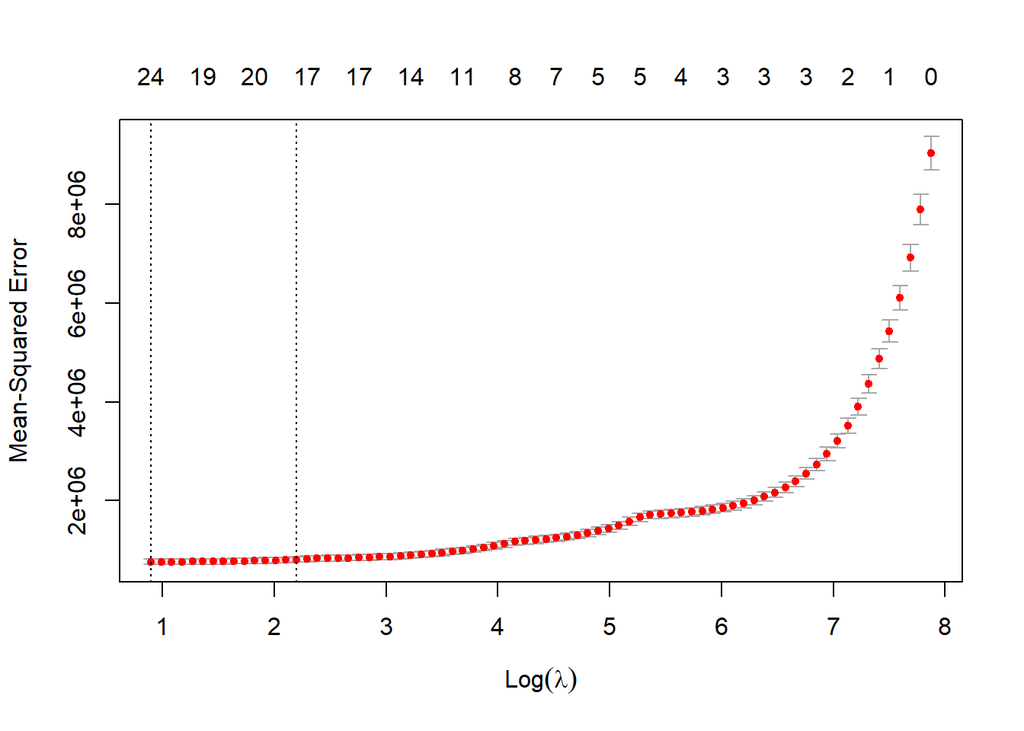

```
## [1] "Performance Summary: Absolute Percentage Errors"
##        1
##  Min.   :0.08663
##  1st Qu.:0.51247
##  Median :0.97779
##  Mean   :1.46280
##  3rd Qu.:2.16000
##  Max.   :4.61424
```

```r
penal_reg <- function(feature_matrix, consumption)
{
  set.seed(50)
  cvfit = cv.glmnet(feature_matrix, consumption[8:(which(wide_format$date_wide=="01.11.2020")-1)], family = 'gaussian')
  print(cvfit)
  print(coef(cvfit, s = 'lambda.1se'))
  plot(cvfit)

  pred <- predict(cvfit, as.matrix(wide_format[(which(wide_format$date_wide=="01.11.2020"):nrow(wide_format)), 2:ncol(wide_format)]), s = c("lambda.1se"))
  ape <- mape(pred, consumption[which(wide_format$date_wide=="01.11.2020"):nrow(wide_format)])
  return(ape)
}

penal0 <- penal_reg(feature_matrix, consumption_0)
```

```r
penal1 <- penal_reg(feature_matrix, consumption_1)
```

```
##
## Call:  cv.glmnet(x = feature_matrix, y = consumption[8:(which(wide_format$date_wide ==      "01.11.2020") - 1)], family = "gaussian")
##
## Measure: Mean-Squared Error
##
##     Lambda Measure    SE Nonzero
## min  0.403  756584 60211      38
## 1se  6.564  809484 66027      21
## 49 x 1 sparse Matrix of class "dgCMatrix"
##                             1
## (Intercept)      1.013692e+03
## lag_2day_hour0  -1.880254e-01
## lag_2day_hour1   .
## lag_2day_hour2   .
## lag_2day_hour3   7.607705e-06
## lag_2day_hour4   9.205491e-02
## lag_2day_hour5   .
## lag_2day_hour6   .
## lag_2day_hour7   9.046193e-02
## lag_2day_hour8   .
## lag_2day_hour9  -4.460468e-01
## lag_2day_hour10 -2.475585e-02
## lag_2day_hour11 -1.375753e-01
## lag_2day_hour12  .
## lag_2day_hour13  1.318174e-01
## lag_2day_hour14  .
## lag_2day_hour15  .
## lag_2day_hour16  1.094204e-01
## lag_2day_hour17  .
## lag_2day_hour18  .
## lag_2day_hour19  .
## lag_2day_hour20  .
## lag_2day_hour21  .
## lag_2day_hour22  2.692571e-01
## lag_2day_hour23  9.803205e-01
## lag_7day_hour0   .
## lag_7day_hour1   6.115796e-02
## lag_7day_hour2   .
## lag_7day_hour3   .
## lag_7day_hour4   1.915704e-02
## lag_7day_hour5   .
## lag_7day_hour6   8.664096e-02
## lag_7day_hour7   1.904730e-01
## lag_7day_hour8   2.319345e-02
## lag_7day_hour9   .
## lag_7day_hour10  .
## lag_7day_hour11  3.349638e-02
## lag_7day_hour12  .
## lag_7day_hour13  .
## lag_7day_hour14  5.506153e-02
## lag_7day_hour15  .
## lag_7day_hour16  .
## lag_7day_hour17  .
## lag_7day_hour18  .
## lag_7day_hour19 -1.203168e-01
## lag_7day_hour20 -2.656084e-01
## lag_7day_hour21  .
## lag_7day_hour22 -1.978201e-04
## lag_7day_hour23  .
```

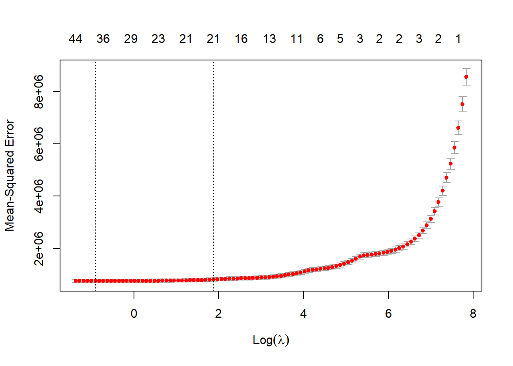

```
## [1] "Performance Summary: Absolute Percentage Errors"
##        1
##  Min.   :0.01492
##  1st Qu.:0.56744
##  Median :1.00514
##  Mean   :1.52726
##  3rd Qu.:2.14857
##  Max.   :4.22616
```

```r
penal2 <- penal_reg(feature_matrix, consumption_2)
```

```
##
## Call:  cv.glmnet(x = feature_matrix, y = consumption[8:(which(wide_format$date_wide ==      "01.11.2020") - 1)], family = "gaussian")
##
## Measure: Mean-Squared Error
##
##     Lambda Measure    SE Nonzero
## min  0.382  778760 69919      40
## 1se  7.490  843484 77162      19
## 49 x 1 sparse Matrix of class "dgCMatrix"
##                             1
## (Intercept)      1.382581e+03
## lag_2day_hour0  -3.612891e-01
## lag_2day_hour1   .
## lag_2day_hour2   .
## lag_2day_hour3   1.398646e-01
## lag_2day_hour4   1.971167e-01
## lag_2day_hour5   .
## lag_2day_hour6   .
## lag_2day_hour7   4.012612e-03
## lag_2day_hour8   .
## lag_2day_hour9  -4.008193e-01
## lag_2day_hour10 -4.034802e-02
## lag_2day_hour11 -9.743486e-02
## lag_2day_hour12  .
## lag_2day_hour13  7.775635e-02
## lag_2day_hour14  .
## lag_2day_hour15  .
## lag_2day_hour16  1.167949e-01
## lag_2day_hour17  .
## lag_2day_hour18  .
## lag_2day_hour19  .
## lag_2day_hour20  .
## lag_2day_hour21  .
## lag_2day_hour22  2.546410e-01
## lag_2day_hour23  9.686381e-01
## lag_7day_hour0   .
## lag_7day_hour1   .
## lag_7day_hour2   .
## lag_7day_hour3   .
## lag_7day_hour4   1.040905e-01
## lag_7day_hour5   .
## lag_7day_hour6   .
## lag_7day_hour7   1.998715e-01
## lag_7day_hour8   8.651328e-02
## lag_7day_hour9   .
## lag_7day_hour10  .
## lag_7day_hour11  1.070586e-03
## lag_7day_hour12  .
## lag_7day_hour13  .
## lag_7day_hour14  5.076785e-02
## lag_7day_hour15  .
## lag_7day_hour16  .
## lag_7day_hour17  .
## lag_7day_hour18  .
## lag_7day_hour19 -8.014736e-02
## lag_7day_hour20 -2.571792e-01
## lag_7day_hour21  .
## lag_7day_hour22 -3.443456e-02
## lag_7day_hour23  .
```

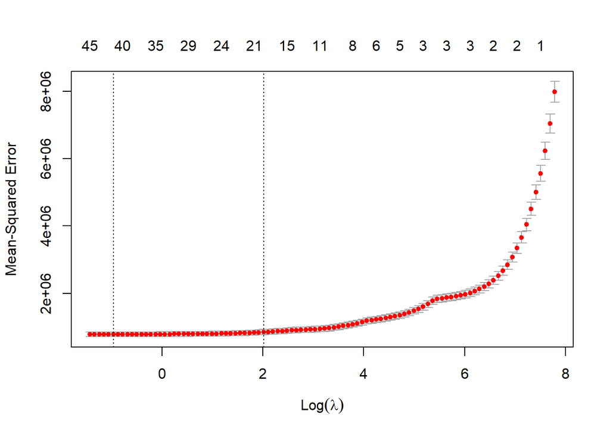

```
## [1] "Performance Summary: Absolute Percentage Errors"
##        1
##  Min.   :0.07679
##  1st Qu.:0.60700
##  Median :1.12007
##  Mean   :1.57146
##  3rd Qu.:1.97331
##  Max.   :6.58002
```

```r
penal3 <- penal_reg(feature_matrix, consumption_3)
```

```
##
## Call:  cv.glmnet(x = feature_matrix, y = consumption[8:(which(wide_format$date_wide ==      "01.11.2020") - 1)], family = "gaussian")
##
## Measure: Mean-Squared Error
##
##     Lambda Measure    SE Nonzero
## min  0.531  779810 70801      37
## 1se  8.652  849344 79829      16
## 49 x 1 sparse Matrix of class "dgCMatrix"
##                             1
## (Intercept)     1366.21109066
## lag_2day_hour0    -0.40496163
## lag_2day_hour1     .
## lag_2day_hour2     .
## lag_2day_hour3     .
## lag_2day_hour4     0.38977757
## lag_2day_hour5     .
## lag_2day_hour6     .
## lag_2day_hour7     .
## lag_2day_hour8     .
## lag_2day_hour9    -0.42613264
## lag_2day_hour10   -0.04399682
## lag_2day_hour11   -0.03631515
## lag_2day_hour12    .
## lag_2day_hour13    0.05130768
## lag_2day_hour14    .
## lag_2day_hour15    .
## lag_2day_hour16    0.10859731
## lag_2day_hour17    .
## lag_2day_hour18    .
## lag_2day_hour19    .
## lag_2day_hour20    .
## lag_2day_hour21    .
## lag_2day_hour22    0.26400393
## lag_2day_hour23    0.93325162
## lag_7day_hour0     .
## lag_7day_hour1     .
## lag_7day_hour2     .
## lag_7day_hour3     .
## lag_7day_hour4     0.07342095
## lag_7day_hour5     .
## lag_7day_hour6     .
## lag_7day_hour7     0.18096401
## lag_7day_hour8     0.11317062
## lag_7day_hour9     .
## lag_7day_hour10    .
## lag_7day_hour11    .
## lag_7day_hour12    .
## lag_7day_hour13    .
## lag_7day_hour14    0.04303395
## lag_7day_hour15    .
## lag_7day_hour16    .
## lag_7day_hour17    .
## lag_7day_hour18    .
## lag_7day_hour19   -0.07971172
## lag_7day_hour20   -0.19691016
## lag_7day_hour21    .
## lag_7day_hour22   -0.06617153
## lag_7day_hour23    .
```

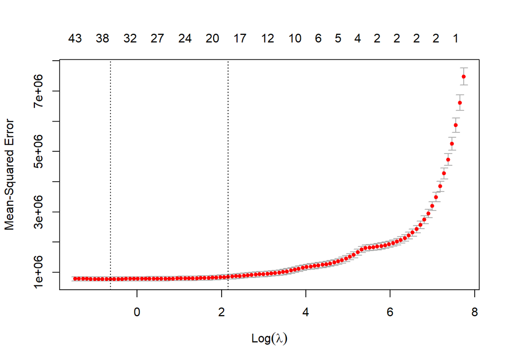

```
## [1] "Performance Summary: Absolute Percentage Errors"
##        1
##  Min.   :0.1810
##  1st Qu.:0.5418
##  Median :1.0635
##  Mean   :1.4210
##  3rd Qu.:1.9574
##  Max.   :4.6065
```

```r
penal4 <- penal_reg(feature_matrix, consumption_4)
```

```
##
## Call:  cv.glmnet(x = feature_matrix, y = consumption[8:(which(wide_format$date_wide ==      "01.11.2020") - 1)], family = "gaussian")
##
## Measure: Mean-Squared Error
##
##     Lambda Measure    SE Nonzero
## min  0.468  768037 69239      37
## 1se  8.362  837174 79425      21
## 49 x 1 sparse Matrix of class "dgCMatrix"
##                             1
## (Intercept)      1.263659e+03
## lag_2day_hour0  -4.453607e-01
## lag_2day_hour1   .
## lag_2day_hour2   .
## lag_2day_hour3   .
## lag_2day_hour4   3.534424e-01
## lag_2day_hour5   5.225318e-02
## lag_2day_hour6   .
## lag_2day_hour7   4.379034e-02
## lag_2day_hour8   .
## lag_2day_hour9  -4.152038e-01
## lag_2day_hour10 -8.578006e-02
## lag_2day_hour11 -2.242372e-02
## lag_2day_hour12  .
## lag_2day_hour13  1.099035e-01
## lag_2day_hour14  .
## lag_2day_hour15  .
## lag_2day_hour16  5.224827e-02
## lag_2day_hour17  .
## lag_2day_hour18  .
## lag_2day_hour19  .
## lag_2day_hour20  .
## lag_2day_hour21  2.105676e-03
## lag_2day_hour22  3.795998e-01
## lag_2day_hour23  7.939363e-01
## lag_7day_hour0   .
## lag_7day_hour1   .
## lag_7day_hour2   .
## lag_7day_hour3   .
## lag_7day_hour4   .
## lag_7day_hour5   3.744065e-02
## lag_7day_hour6   3.649995e-02
## lag_7day_hour7   2.067084e-01
## lag_7day_hour8   9.938061e-02
## lag_7day_hour9   .
## lag_7day_hour10  .
## lag_7day_hour11  .
## lag_7day_hour12  .
## lag_7day_hour13  .
## lag_7day_hour14  4.523021e-02
## lag_7day_hour15  .
## lag_7day_hour16  .
## lag_7day_hour17  .
## lag_7day_hour18  .
## lag_7day_hour19 -1.308256e-01
## lag_7day_hour20 -6.058996e-02
## lag_7day_hour21  .
## lag_7day_hour22 -1.294471e-01
## lag_7day_hour23 -2.373403e-02
```

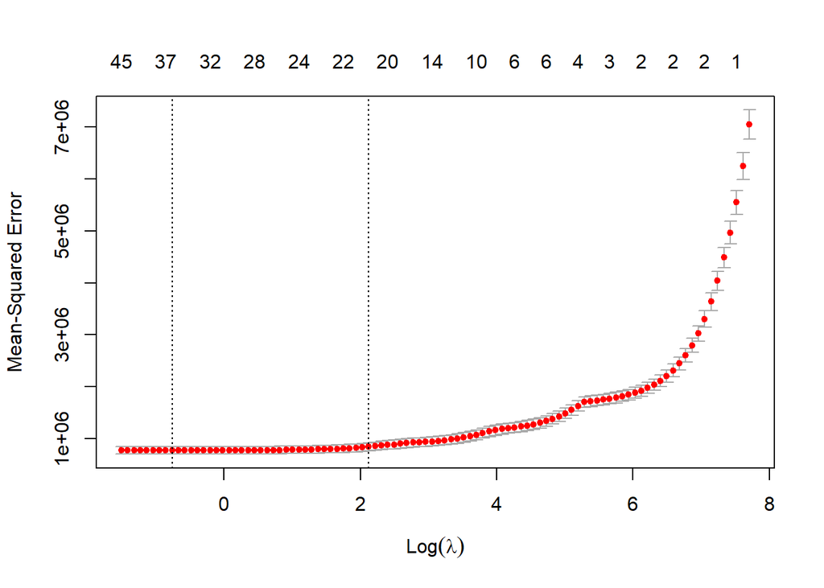

```
## [1] "Performance Summary: Absolute Percentage Errors"
##        1
##  Min.   :0.2339
##  1st Qu.:0.5776
##  Median :1.1637
##  Mean   :1.4124
##  3rd Qu.:2.0537
##  Max.   :3.7670
```

```r
penal5 <- penal_reg(feature_matrix, consumption_5)
```

```
##
## Call:  cv.glmnet(x = feature_matrix, y = consumption[8:(which(wide_format$date_wide ==      "01.11.2020") - 1)], family = "gaussian")
##
## Measure: Mean-Squared Error
##
##     Lambda Measure    SE Nonzero
## min  0.364  771962 59089      37
## 1se  7.155  827692 68469      21
## 49 x 1 sparse Matrix of class "dgCMatrix"
##                             1
## (Intercept)      6.557551e+02
## lag_2day_hour0  -4.196356e-01
## lag_2day_hour1  -2.684391e-01
## lag_2day_hour2   .
## lag_2day_hour3   .
## lag_2day_hour4   .
## lag_2day_hour5   6.129843e-01
## lag_2day_hour6   1.500019e-01
## lag_2day_hour7   2.333471e-04
## lag_2day_hour8   .
## lag_2day_hour9  -5.587474e-01
## lag_2day_hour10  .
## lag_2day_hour11 -8.075969e-03
## lag_2day_hour12  .
## lag_2day_hour13  1.644290e-01
## lag_2day_hour14  .
## lag_2day_hour15  .
## lag_2day_hour16  .
## lag_2day_hour17  .
## lag_2day_hour18  .
## lag_2day_hour19  .
## lag_2day_hour20  4.348724e-02
## lag_2day_hour21  .
## lag_2day_hour22  4.093479e-01
## lag_2day_hour23  7.177443e-01
## lag_7day_hour0   .
## lag_7day_hour1   .
## lag_7day_hour2   .
## lag_7day_hour3   .
## lag_7day_hour4   .
## lag_7day_hour5   .
## lag_7day_hour6   4.230409e-02
## lag_7day_hour7   2.710436e-01
## lag_7day_hour8   9.846431e-02
## lag_7day_hour9   .
## lag_7day_hour10  .
## lag_7day_hour11  .
## lag_7day_hour12  .
## lag_7day_hour13  .
## lag_7day_hour14  2.585036e-02
## lag_7day_hour15  2.010302e-02
## lag_7day_hour16  .
## lag_7day_hour17  .
## lag_7day_hour18  .
## lag_7day_hour19 -9.520664e-02
## lag_7day_hour20 -1.232332e-04
## lag_7day_hour21 -1.589070e-01
## lag_7day_hour22 -9.952538e-02
## lag_7day_hour23 -4.166174e-03
```

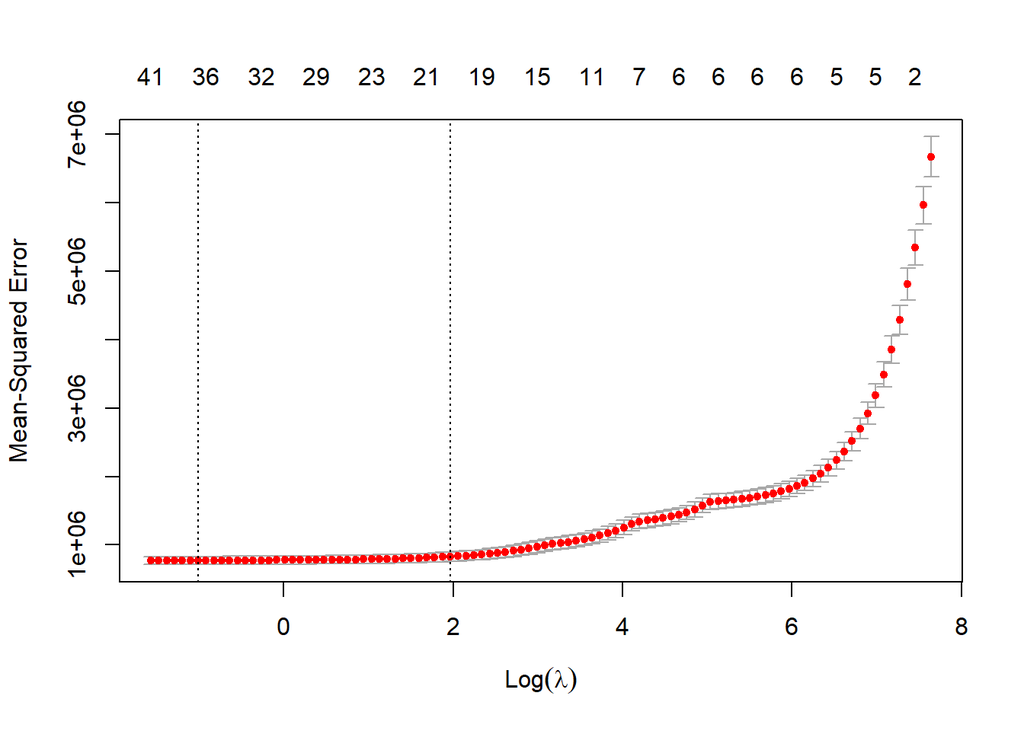

```
## [1] "Performance Summary: Absolute Percentage Errors"
##        1
##  Min.   :0.01737
##  1st Qu.:0.56549
##  Median :1.27406
##  Mean   :1.39862
##  3rd Qu.:1.96662
##  Max.   :4.07586
```

```r
penal6 <- penal_reg(feature_matrix, consumption_6)
```

```
##
## Call:  cv.glmnet(x = feature_matrix, y = consumption[8:(which(wide_format$date_wide ==      "01.11.2020") - 1)], family = "gaussian")
##
## Measure: Mean-Squared Error
##
##     Lambda Measure    SE Nonzero
## min  0.395  898920 61150      40
## 1se  6.438  957489 67382      23
## 49 x 1 sparse Matrix of class "dgCMatrix"
##                             1
## (Intercept)      1.390399e+03
## lag_2day_hour0  -5.108045e-01
## lag_2day_hour1  -7.493214e-02
## lag_2day_hour2  -2.308124e-02
## lag_2day_hour3   .
## lag_2day_hour4   .
## lag_2day_hour5   2.702138e-03
## lag_2day_hour6   7.647332e-01
## lag_2day_hour7   .
## lag_2day_hour8   .
## lag_2day_hour9  -6.672688e-01
## lag_2day_hour10  .
## lag_2day_hour11 -1.700730e-02
## lag_2day_hour12  .
## lag_2day_hour13  2.255259e-01
## lag_2day_hour14  .
## lag_2day_hour15  .
## lag_2day_hour16  .
## lag_2day_hour17  .
## lag_2day_hour18  .
## lag_2day_hour19  .
## lag_2day_hour20  1.153732e-01
## lag_2day_hour21  1.348076e-02
## lag_2day_hour22  3.577259e-01
## lag_2day_hour23  6.758433e-01
## lag_7day_hour0  -7.723556e-03
## lag_7day_hour1   .
## lag_7day_hour2  -2.078885e-01
## lag_7day_hour3   .
## lag_7day_hour4  -1.498331e-02
## lag_7day_hour5   .
## lag_7day_hour6   6.607492e-03
## lag_7day_hour7   5.490324e-01
## lag_7day_hour8   7.678841e-02
## lag_7day_hour9   .
## lag_7day_hour10  .
## lag_7day_hour11  .
## lag_7day_hour12  .
## lag_7day_hour13  .
## lag_7day_hour14  .
## lag_7day_hour15  5.440703e-02
## lag_7day_hour16  9.910347e-03
## lag_7day_hour17  .
## lag_7day_hour18  .
## lag_7day_hour19  .
## lag_7day_hour20 -2.570676e-01
## lag_7day_hour21 -4.808248e-02
## lag_7day_hour22 -8.819547e-02
## lag_7day_hour23  .
```

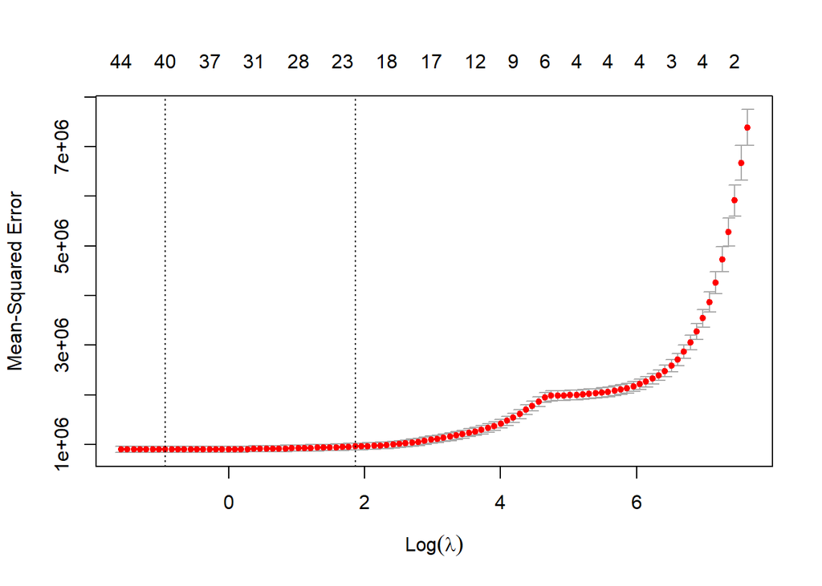

```
## [1] "Performance Summary: Absolute Percentage Errors"
##        1
##  Min.   :0.04142
##  1st Qu.:0.61581
##  Median :1.32808
##  Mean   :1.60930
##  3rd Qu.:2.29033
##  Max.   :4.46175
```

```r
penal7 <- penal_reg(feature_matrix, consumption_7)
```

```
##
## Call:  cv.glmnet(x = feature_matrix, y = consumption[8:(which(wide_format$date_wide ==      "01.11.2020") - 1)], family = "gaussian")
##
## Measure: Mean-Squared Error
##
##     Lambda Measure     SE Nonzero
## min  0.637 1464292 104782      41
## 1se  7.160 1567904 119947      23
## 49 x 1 sparse Matrix of class "dgCMatrix"
##                             1
## (Intercept)      2.342037e+03
## lag_2day_hour0  -3.184093e-01
## lag_2day_hour1  -3.038796e-01
## lag_2day_hour2  -8.142757e-02
## lag_2day_hour3   .
## lag_2day_hour4   .
## lag_2day_hour5   4.514024e-01
## lag_2day_hour6   7.143571e-02
## lag_2day_hour7   3.842079e-01
## lag_2day_hour8   .
## lag_2day_hour9  -8.059740e-01
## lag_2day_hour10  .
## lag_2day_hour11 -4.809397e-02
## lag_2day_hour12  .
## lag_2day_hour13  3.194251e-01
## lag_2day_hour14 -1.347877e-04
## lag_2day_hour15  .
## lag_2day_hour16  .
## lag_2day_hour17  .
## lag_2day_hour18  .
## lag_2day_hour19  .
## lag_2day_hour20  1.439161e-01
## lag_2day_hour21  1.498415e-01
## lag_2day_hour22  2.325094e-01
## lag_2day_hour23  7.136293e-01
## lag_7day_hour0  -9.554961e-02
## lag_7day_hour1   .
## lag_7day_hour2   .
## lag_7day_hour3   .
## lag_7day_hour4  -2.603073e-01
## lag_7day_hour5  -3.911432e-01
## lag_7day_hour6   .
## lag_7day_hour7   9.204570e-01
## lag_7day_hour8   1.876899e-01
## lag_7day_hour9   .
## lag_7day_hour10  .
## lag_7day_hour11  .
## lag_7day_hour12  .
## lag_7day_hour13  .
## lag_7day_hour14  .
## lag_7day_hour15  9.356510e-03
## lag_7day_hour16  8.754772e-02
## lag_7day_hour17  .
## lag_7day_hour18  .
## lag_7day_hour19 -1.346506e-02
## lag_7day_hour20 -4.492647e-01
## lag_7day_hour21  .
## lag_7day_hour22  .
## lag_7day_hour23  .
```

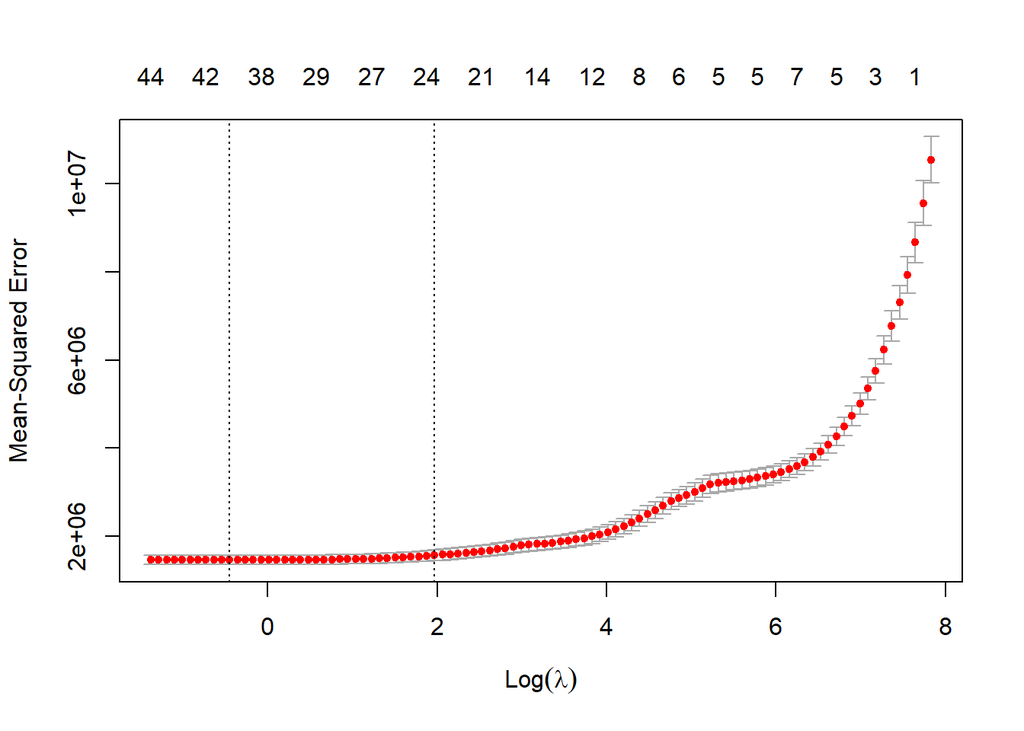

```
## [1] "Performance Summary: Absolute Percentage Errors"
##        1
##  Min.   :0.06042
##  1st Qu.:0.98275
##  Median :1.49508
##  Mean   :1.76669
##  3rd Qu.:2.26199
##  Max.   :5.94524
```

```r
penal8 <- penal_reg(feature_matrix, consumption_8)
```

```
##
## Call:  cv.glmnet(x = feature_matrix, y = consumption[8:(which(wide_format$date_wide ==      "01.11.2020") - 1)], family = "gaussian")
##
## Measure: Mean-Squared Error
##
##     Lambda Measure     SE Nonzero
## min  0.444 3253306 260469      46
## 1se 10.505 3484275 293869      22
## 49 x 1 sparse Matrix of class "dgCMatrix"
##                             1
## (Intercept)      4.571084e+03
## lag_2day_hour0  -7.777347e-01
## lag_2day_hour1  -1.186393e-01
## lag_2day_hour2  -1.181187e-01
## lag_2day_hour3   .
## lag_2day_hour4   .
## lag_2day_hour5   8.934987e-01
## lag_2day_hour6   1.130431e-01
## lag_2day_hour7   1.455200e-01
## lag_2day_hour8   .
## lag_2day_hour9  -8.099540e-01
## lag_2day_hour10  .
## lag_2day_hour11 -2.708192e-01
## lag_2day_hour12  .
## lag_2day_hour13  7.828677e-01
## lag_2day_hour14 -2.154561e-01
## lag_2day_hour15  .
## lag_2day_hour16  .
## lag_2day_hour17 -1.421351e-03
## lag_2day_hour18  .
## lag_2day_hour19  .
## lag_2day_hour20  3.172822e-01
## lag_2day_hour21  1.491967e-01
## lag_2day_hour22  7.248588e-02
## lag_2day_hour23  9.385901e-01
## lag_7day_hour0   .
## lag_7day_hour1   .
## lag_7day_hour2   .
## lag_7day_hour3   .
## lag_7day_hour4  -2.285635e-01
## lag_7day_hour5  -9.120404e-01
## lag_7day_hour6   .
## lag_7day_hour7   6.004488e-01
## lag_7day_hour8   8.499723e-01
## lag_7day_hour9   .
## lag_7day_hour10  .
## lag_7day_hour11  .
## lag_7day_hour12  .
## lag_7day_hour13  .
## lag_7day_hour14  .
## lag_7day_hour15  .
## lag_7day_hour16  1.272014e-01
## lag_7day_hour17  .
## lag_7day_hour18  .
## lag_7day_hour19 -1.907538e-01
## lag_7day_hour20 -4.533332e-01
## lag_7day_hour21  .
## lag_7day_hour22  .
## lag_7day_hour23  .
```

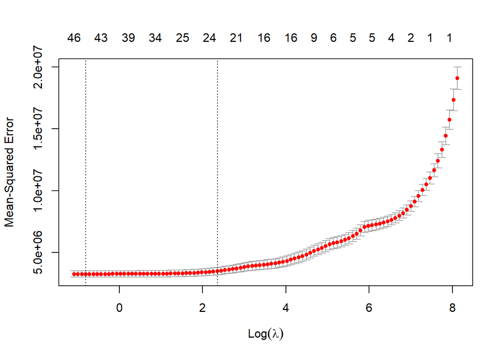

```
## [1] "Performance Summary: Absolute Percentage Errors"
##        1
##  Min.   :0.1765
##  1st Qu.:0.8469
##  Median :1.8628
##  Mean   :2.5155
##  3rd Qu.:3.3536
##  Max.   :8.4645
```

```r
penal9 <- penal_reg(feature_matrix, consumption_9)
```

```
##
## Call:  cv.glmnet(x = feature_matrix, y = consumption[8:(which(wide_format$date_wide ==      "01.11.2020") - 1)], family = "gaussian")
##
## Measure: Mean-Squared Error
##
##     Lambda Measure     SE Nonzero
## min  0.372 4276775 371075      46
## 1se 14.023 4647433 433185      21
## 49 x 1 sparse Matrix of class "dgCMatrix"
##                             1
## (Intercept)     5475.40990596
## lag_2day_hour0    -0.52376638
## lag_2day_hour1    -0.26430062
## lag_2day_hour2    -0.15796671
## lag_2day_hour3     .
## lag_2day_hour4     .
## lag_2day_hour5     0.75221369
## lag_2day_hour6     0.07844537
## lag_2day_hour7     0.27445854
## lag_2day_hour8     .
## lag_2day_hour9    -1.02553588
## lag_2day_hour10    .
## lag_2day_hour11   -0.13445508
## lag_2day_hour12    .
## lag_2day_hour13    0.91802470
## lag_2day_hour14   -0.24027826
## lag_2day_hour15    .
## lag_2day_hour16    .
## lag_2day_hour17    .
## lag_2day_hour18    .
## lag_2day_hour19    .
## lag_2day_hour20    0.35868097
## lag_2day_hour21    .
## lag_2day_hour22    .
## lag_2day_hour23    1.11405468
## lag_7day_hour0     .
## lag_7day_hour1     .
## lag_7day_hour2     .
## lag_7day_hour3     .
## lag_7day_hour4    -0.29637277
## lag_7day_hour5    -0.86225852
## lag_7day_hour6     .
## lag_7day_hour7     0.36993291
## lag_7day_hour8     0.91050866
## lag_7day_hour9     0.17969909
## lag_7day_hour10    .
## lag_7day_hour11    .
## lag_7day_hour12    .
## lag_7day_hour13    .
## lag_7day_hour14    .
## lag_7day_hour15    0.03183394
## lag_7day_hour16    0.08119562
## lag_7day_hour17    .
## lag_7day_hour18    .
## lag_7day_hour19   -0.21485661
## lag_7day_hour20   -0.46953578
## lag_7day_hour21    .
## lag_7day_hour22    .
## lag_7day_hour23    .
```

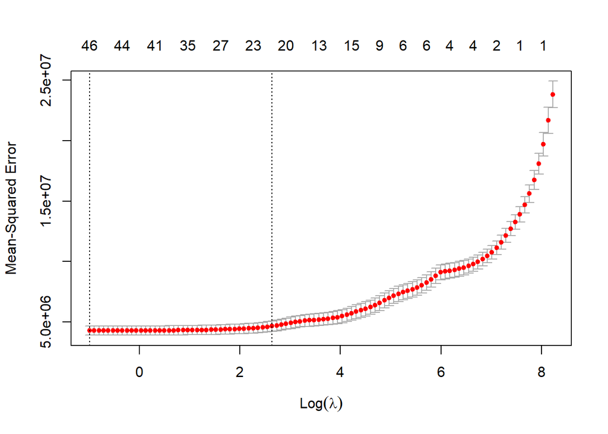

```
## [1] "Performance Summary: Absolute Percentage Errors"
##        1
##  Min.   : 0.2378
##  1st Qu.: 1.6075
##  Median : 2.8847
##  Mean   : 3.6642
##  3rd Qu.: 4.1329
##  Max.   :12.4225
```

```r
penal10 <- penal_reg(feature_matrix, consumption_10)
```

```
##
## Call:  cv.glmnet(x = feature_matrix, y = consumption[8:(which(wide_format$date_wide ==      "01.11.2020") - 1)], family = "gaussian")
##
## Measure: Mean-Squared Error
##
##     Lambda Measure     SE Nonzero
## min  0.632 4465942 414303      43
## 1se 14.940 4868210 484469      21
## 49 x 1 sparse Matrix of class "dgCMatrix"
##                             1
## (Intercept)      6.326359e+03
## lag_2day_hour0  -3.033225e-01
## lag_2day_hour1  -2.299445e-01
## lag_2day_hour2  -3.191103e-01
## lag_2day_hour3   .
## lag_2day_hour4   .
## lag_2day_hour5   6.378491e-01
## lag_2day_hour6   2.423625e-03
## lag_2day_hour7   4.110395e-01
## lag_2day_hour8   .
## lag_2day_hour9  -1.170392e+00
## lag_2day_hour10  .
## lag_2day_hour11  .
## lag_2day_hour12  .
## lag_2day_hour13  8.753008e-01
## lag_2day_hour14 -1.362690e-01
## lag_2day_hour15  .
## lag_2day_hour16  .
## lag_2day_hour17  .
## lag_2day_hour18  .
## lag_2day_hour19  .
## lag_2day_hour20  2.303159e-01
## lag_2day_hour21  .
## lag_2day_hour22  .
## lag_2day_hour23  1.114672e+00
## lag_7day_hour0   .
## lag_7day_hour1   .
## lag_7day_hour2   .
## lag_7day_hour3   .
## lag_7day_hour4  -3.773686e-01
## lag_7day_hour5  -6.419131e-01
## lag_7day_hour6   .
## lag_7day_hour7   3.042015e-01
## lag_7day_hour8   5.705132e-01
## lag_7day_hour9   3.859949e-01
## lag_7day_hour10  3.659372e-02
## lag_7day_hour11  .
## lag_7day_hour12  .
## lag_7day_hour13  .
## lag_7day_hour14  .
## lag_7day_hour15  8.670848e-02
## lag_7day_hour16  3.276169e-02
## lag_7day_hour17  .
## lag_7day_hour18  .
## lag_7day_hour19 -2.432038e-01
## lag_7day_hour20 -4.164767e-01
## lag_7day_hour21  .
## lag_7day_hour22  .
## lag_7day_hour23  .
```

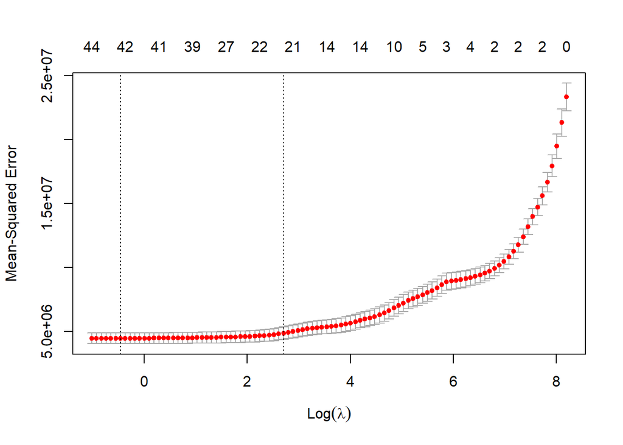

```
## [1] "Performance Summary: Absolute Percentage Errors"
##        1
##  Min.   : 0.4514
##  1st Qu.: 2.1704
##  Median : 3.5718
##  Mean   : 4.3052
##  3rd Qu.: 5.2846
##  Max.   :13.9194
```

```r
penal11 <- penal_reg(feature_matrix, consumption_11)
```

```
##
## Call:  cv.glmnet(x = feature_matrix, y = consumption[8:(which(wide_format$date_wide ==      "01.11.2020") - 1)], family = "gaussian")
##
## Measure: Mean-Squared Error
##
##     Lambda Measure     SE Nonzero
## min   0.47 4702123 439132      44
## 1se  14.70 5106865 514588      20
## 49 x 1 sparse Matrix of class "dgCMatrix"
##                             1
## (Intercept)      6.820308e+03
## lag_2day_hour0  -2.571035e-01
## lag_2day_hour1  -2.761751e-01
## lag_2day_hour2  -3.478368e-01
## lag_2day_hour3   .
## lag_2day_hour4   .
## lag_2day_hour5   6.581154e-01
## lag_2day_hour6   .
## lag_2day_hour7   4.298813e-01
## lag_2day_hour8   .
## lag_2day_hour9  -1.228834e+00
## lag_2day_hour10  .
## lag_2day_hour11  .
## lag_2day_hour12  .
## lag_2day_hour13  9.546188e-01
## lag_2day_hour14 -1.222909e-01
## lag_2day_hour15  .
## lag_2day_hour16  .
## lag_2day_hour17  .
## lag_2day_hour18  .
## lag_2day_hour19  .
## lag_2day_hour20  1.283281e-01
## lag_2day_hour21  .
## lag_2day_hour22  .
## lag_2day_hour23  1.171003e+00
## lag_7day_hour0   .
## lag_7day_hour1   .
## lag_7day_hour2   .
## lag_7day_hour3   .
## lag_7day_hour4  -3.529419e-01
## lag_7day_hour5  -6.248272e-01
## lag_7day_hour6   .
## lag_7day_hour7   2.501378e-01
## lag_7day_hour8   5.303451e-01
## lag_7day_hour9   3.069111e-01
## lag_7day_hour10  1.017810e-01
## lag_7day_hour11  .
## lag_7day_hour12  .
## lag_7day_hour13  .
## lag_7day_hour14  .
## lag_7day_hour15  1.432563e-01
## lag_7day_hour16  3.503198e-03
## lag_7day_hour17  .
## lag_7day_hour18  .
## lag_7day_hour19 -2.868054e-01
## lag_7day_hour20 -3.311231e-01
## lag_7day_hour21  .
## lag_7day_hour22  .
## lag_7day_hour23  .
```

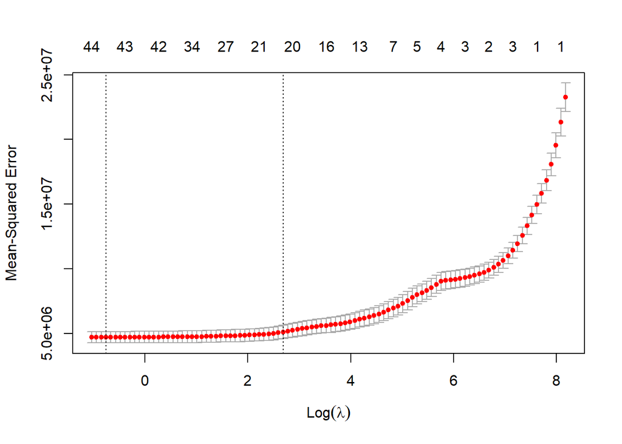

```
## [1] "Performance Summary: Absolute Percentage Errors"
##        1
##  Min.   : 0.804
##  1st Qu.: 1.935
##  Median : 3.957
##  Mean   : 4.516
##  3rd Qu.: 5.440
##  Max.   :14.417
```

```r
penal12 <- penal_reg(feature_matrix, consumption_12)
```

```
##
## Call:  cv.glmnet(x = feature_matrix, y = consumption[8:(which(wide_format$date_wide ==      "01.11.2020") - 1)], family = "gaussian")
##
## Measure: Mean-Squared Error
##
##     Lambda Measure     SE Nonzero
## min  0.569 4150667 375608      43
## 1se 13.443 4512334 428827      22
## 49 x 1 sparse Matrix of class "dgCMatrix"
##                             1
## (Intercept)     4955.89571021
## lag_2day_hour0    -0.06644982
## lag_2day_hour1    -0.15029453
## lag_2day_hour2    -0.40656500
## lag_2day_hour3     .
## lag_2day_hour4     .
## lag_2day_hour5     0.32430487
## lag_2day_hour6     .
## lag_2day_hour7     0.52455255
## lag_2day_hour8    -0.15459082
## lag_2day_hour9    -1.08205134
## lag_2day_hour10    .
## lag_2day_hour11    .
## lag_2day_hour12    .
## lag_2day_hour13    0.89728413
## lag_2day_hour14   -0.05796870
## lag_2day_hour15    .
## lag_2day_hour16    .
## lag_2day_hour17    .
## lag_2day_hour18    .
## lag_2day_hour19    .
## lag_2day_hour20    0.05852317
## lag_2day_hour21    .
## lag_2day_hour22    .
## lag_2day_hour23    1.12682836
## lag_7day_hour0     .
## lag_7day_hour1     .
## lag_7day_hour2     .
## lag_7day_hour3     .
## lag_7day_hour4    -0.34980253
## lag_7day_hour5    -0.49217328
## lag_7day_hour6     .
## lag_7day_hour7     0.27550570
## lag_7day_hour8     0.27130870
## lag_7day_hour9     0.22579695
## lag_7day_hour10    0.15162680
## lag_7day_hour11    .
## lag_7day_hour12    0.03504888
## lag_7day_hour13    0.06839870
## lag_7day_hour14    .
## lag_7day_hour15    0.07048037
## lag_7day_hour16    .
## lag_7day_hour17    .
## lag_7day_hour18    .
## lag_7day_hour19   -0.23919384
## lag_7day_hour20   -0.19137633
## lag_7day_hour21    .
## lag_7day_hour22    .
## lag_7day_hour23    .
```

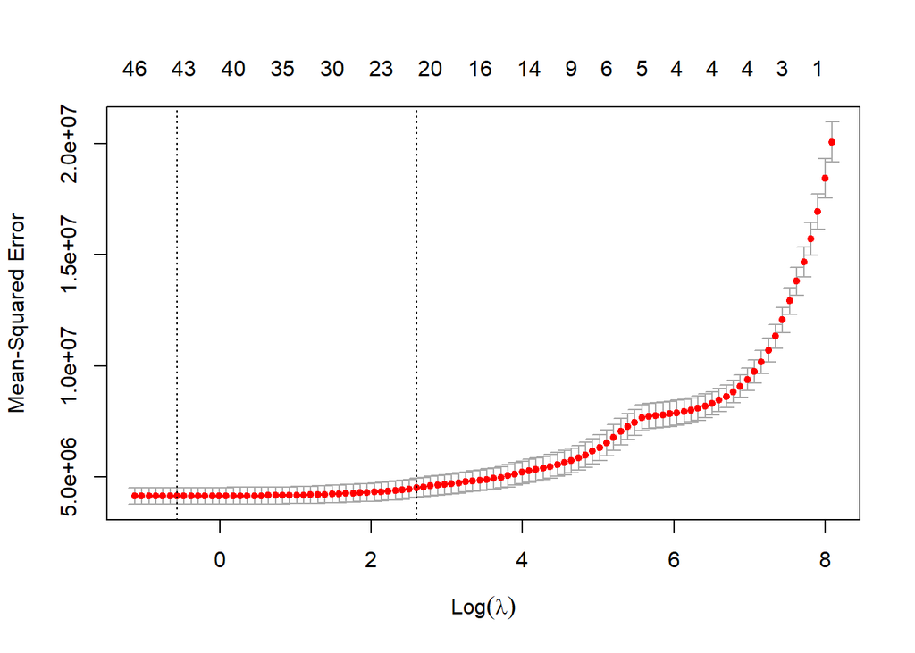

```
## [1] "Performance Summary: Absolute Percentage Errors"
##        1
##  Min.   : 0.4362
##  1st Qu.: 2.0275
##  Median : 4.3197
##  Mean   : 4.7494
##  3rd Qu.: 6.6704
##  Max.   :13.3190
```

```r
penal13 <- penal_reg(feature_matrix, consumption_13)
```

```
##
## Call:  cv.glmnet(x = feature_matrix, y = consumption[8:(which(wide_format$date_wide ==      "01.11.2020") - 1)], family = "gaussian")
##
## Measure: Mean-Squared Error
##
##     Lambda Measure     SE Nonzero
## min  0.356 4524377 362589      45
## 1se 10.128 4852970 419582      20
## 49 x 1 sparse Matrix of class "dgCMatrix"
##                             1
## (Intercept)     5373.28110687
## lag_2day_hour0    -0.43492914
## lag_2day_hour1    -0.12940633
## lag_2day_hour2    -0.43388392
## lag_2day_hour3     .
## lag_2day_hour4     .
## lag_2day_hour5     0.77964974
## lag_2day_hour6     .
## lag_2day_hour7     0.45031394
## lag_2day_hour8    -0.14633193
## lag_2day_hour9    -1.20246002
## lag_2day_hour10    .
## lag_2day_hour11    .
## lag_2day_hour12    .
## lag_2day_hour13    1.04467294
## lag_2day_hour14   -0.16200341
## lag_2day_hour15    .
## lag_2day_hour16    .
## lag_2day_hour17    .
## lag_2day_hour18    0.05716202
## lag_2day_hour19    .
## lag_2day_hour20    .
## lag_2day_hour21    .
## lag_2day_hour22    .
## lag_2day_hour23    1.25490688
## lag_7day_hour0     .
## lag_7day_hour1     .
## lag_7day_hour2     .
## lag_7day_hour3     .
## lag_7day_hour4    -0.05578802
## lag_7day_hour5    -0.91163103
## lag_7day_hour6     .
## lag_7day_hour7     0.29164657
## lag_7day_hour8     0.49994545
## lag_7day_hour9     .
## lag_7day_hour10    .
## lag_7day_hour11    .
## lag_7day_hour12   -0.07235005
## lag_7day_hour13    0.47032108
## lag_7day_hour14    .
## lag_7day_hour15    .
## lag_7day_hour16    .
## lag_7day_hour17    0.01227551
## lag_7day_hour18    .
## lag_7day_hour19   -0.36458335
## lag_7day_hour20   -0.06699591
## lag_7day_hour21    .
## lag_7day_hour22    .
## lag_7day_hour23    .
```

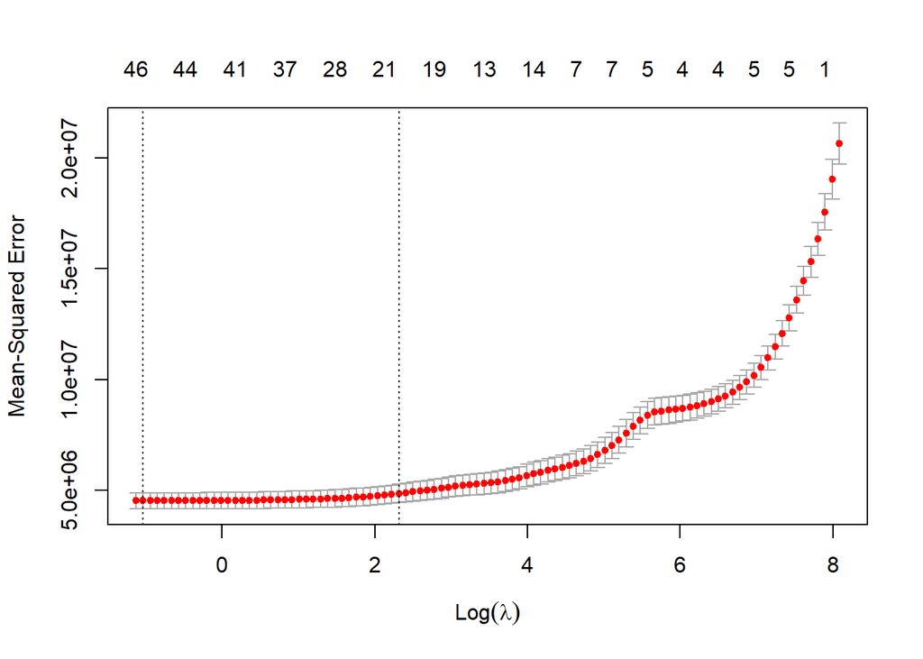

```
## [1] "Performance Summary: Absolute Percentage Errors"
##        1
##  Min.   : 0.1828
##  1st Qu.: 1.7514
##  Median : 3.8908
##  Mean   : 4.6961
##  3rd Qu.: 6.9006
##  Max.   :11.9416
```

```r
penal14 <- penal_reg(feature_matrix, consumption_14)
```

```
##
## Call:  cv.glmnet(x = feature_matrix, y = consumption[8:(which(wide_format$date_wide ==      "01.11.2020") - 1)], family = "gaussian")
##
## Measure: Mean-Squared Error
##
##     Lambda Measure     SE Nonzero
## min  0.414 5050949 412117      45
## 1se 12.939 5444697 490796      20
## 49 x 1 sparse Matrix of class "dgCMatrix"
##                             1
## (Intercept)      5.628386e+03
## lag_2day_hour0  -5.089094e-01
## lag_2day_hour1  -2.167973e-01
## lag_2day_hour2  -1.645090e-01
## lag_2day_hour3   .
## lag_2day_hour4   .
## lag_2day_hour5   7.161692e-01
## lag_2day_hour6   2.829224e-02
## lag_2day_hour7   3.035199e-01
## lag_2day_hour8  -5.929468e-03
## lag_2day_hour9  -1.287881e+00
## lag_2day_hour10  .
## lag_2day_hour11  .
## lag_2day_hour12  .
## lag_2day_hour13  8.993494e-01
## lag_2day_hour14 -4.229559e-06
## lag_2day_hour15  .
## lag_2day_hour16  .
## lag_2day_hour17  .
## lag_2day_hour18  .
## lag_2day_hour19  .
## lag_2day_hour20  9.379388e-02
## lag_2day_hour21  .
## lag_2day_hour22  .
## lag_2day_hour23  1.261204e+00
## lag_7day_hour0   .
## lag_7day_hour1   .
## lag_7day_hour2   .
## lag_7day_hour3   .
## lag_7day_hour4  -1.777170e-01
## lag_7day_hour5  -7.962748e-01
## lag_7day_hour6   .
## lag_7day_hour7   1.754781e-01
## lag_7day_hour8   6.582315e-01
## lag_7day_hour9   .
## lag_7day_hour10  .
## lag_7day_hour11  .
## lag_7day_hour12  .
## lag_7day_hour13  .
## lag_7day_hour14  .
## lag_7day_hour15  7.730628e-02
## lag_7day_hour16  3.651353e-01
## lag_7day_hour17  .
## lag_7day_hour18  .
## lag_7day_hour19 -4.067477e-01
## lag_7day_hour20 -1.354478e-01
## lag_7day_hour21  .
## lag_7day_hour22  .
## lag_7day_hour23  .
```

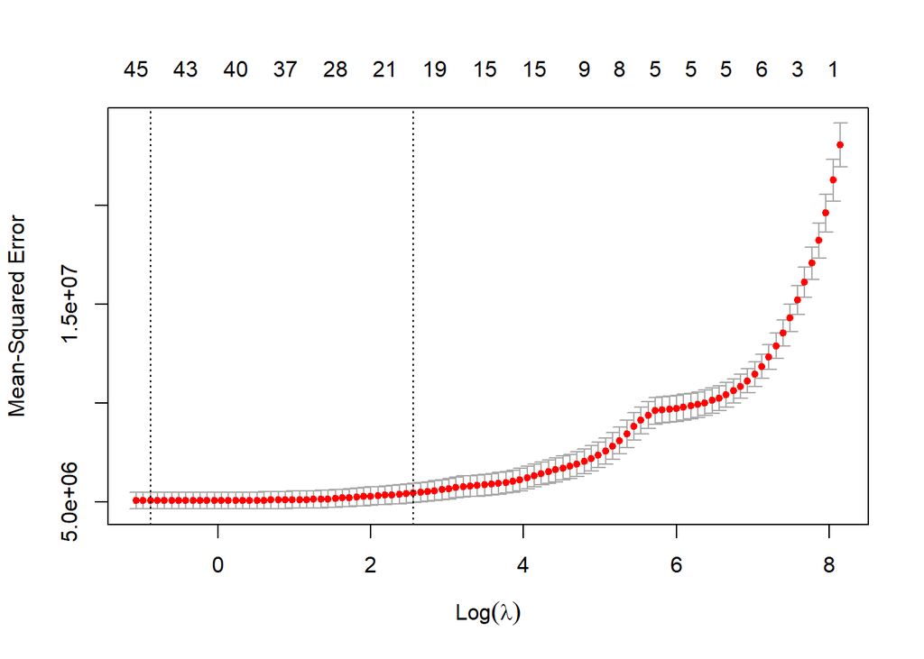

```
## [1] "Performance Summary: Absolute Percentage Errors"
##        1
##  Min.   : 0.1361
##  1st Qu.: 1.5053
##  Median : 3.5962
##  Mean   : 4.4015
##  3rd Qu.: 6.5389
##  Max.   :12.4826
```

```r
penal15 <- penal_reg(feature_matrix, consumption_15)
```

```
##
## Call:  cv.glmnet(x = feature_matrix, y = consumption[8:(which(wide_format$date_wide ==      "01.11.2020") - 1)], family = "gaussian")
##
## Measure: Mean-Squared Error
##
##     Lambda Measure     SE Nonzero
## min  0.345 4913808 391253      46
## 1se 11.822 5282303 459462      18
## 49 x 1 sparse Matrix of class "dgCMatrix"
##                             1
## (Intercept)      5.031680e+03
## lag_2day_hour0  -6.980394e-01
## lag_2day_hour1   .
## lag_2day_hour2  -2.134211e-01
## lag_2day_hour3   .
## lag_2day_hour4   .
## lag_2day_hour5   8.053544e-01
## lag_2day_hour6   .
## lag_2day_hour7   2.481350e-01
## lag_2day_hour8   .
## lag_2day_hour9  -1.246201e+00
## lag_2day_hour10  .
## lag_2day_hour11 -1.644058e-04
## lag_2day_hour12  .
## lag_2day_hour13  8.060400e-01
## lag_2day_hour14  .
## lag_2day_hour15  .
## lag_2day_hour16  .
## lag_2day_hour17  .
## lag_2day_hour18  2.862483e-02
## lag_2day_hour19  .
## lag_2day_hour20  1.929432e-01
## lag_2day_hour21  .
## lag_2day_hour22  .
## lag_2day_hour23  1.210073e+00
## lag_7day_hour0   .
## lag_7day_hour1   .
## lag_7day_hour2   .
## lag_7day_hour3   .
## lag_7day_hour4  -3.172524e-02
## lag_7day_hour5  -1.000406e+00
## lag_7day_hour6   .
## lag_7day_hour7   2.844927e-01
## lag_7day_hour8   5.757111e-01
## lag_7day_hour9   .
## lag_7day_hour10  .
## lag_7day_hour11  .
## lag_7day_hour12 -4.428168e-02
## lag_7day_hour13  .
## lag_7day_hour14  .
## lag_7day_hour15  .
## lag_7day_hour16  5.315165e-01
## lag_7day_hour17  .
## lag_7day_hour18  .
## lag_7day_hour19 -4.211847e-01
## lag_7day_hour20 -1.351637e-01
## lag_7day_hour21  .
## lag_7day_hour22  .
## lag_7day_hour23  .
```

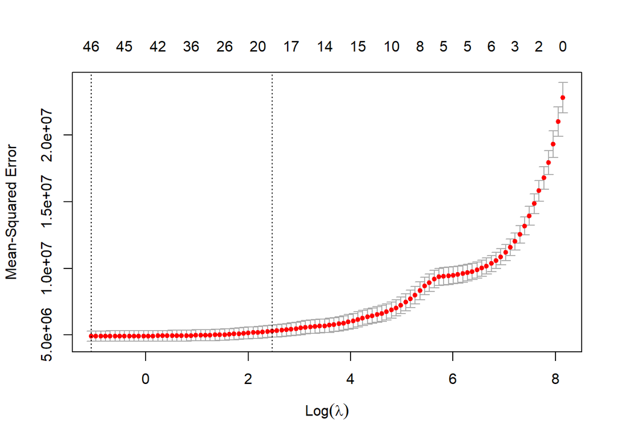

```
## [1] "Performance Summary: Absolute Percentage Errors"
##        1
##  Min.   : 0.3025
##  1st Qu.: 1.4181
##  Median : 3.3862
##  Mean   : 3.9271
##  3rd Qu.: 5.7883
##  Max.   :11.0238
```

```r
penal16 <- penal_reg(feature_matrix, consumption_16)
```

```
##
## Call:  cv.glmnet(x = feature_matrix, y = consumption[8:(which(wide_format$date_wide ==      "01.11.2020") - 1)], family = "gaussian")
##
## Measure: Mean-Squared Error
##
##     Lambda Measure     SE Nonzero
## min  0.498 4587191 356804      46
## 1se 10.726 4924189 417060      21
## 49 x 1 sparse Matrix of class "dgCMatrix"
##                             1
## (Intercept)      5.061689e+03
## lag_2day_hour0  -7.477915e-01
## lag_2day_hour1   .
## lag_2day_hour2  -1.741247e-01
## lag_2day_hour3   .
## lag_2day_hour4   .
## lag_2day_hour5   8.359559e-01
## lag_2day_hour6   .
## lag_2day_hour7   2.118732e-01
## lag_2day_hour8   .
## lag_2day_hour9  -1.158787e+00
## lag_2day_hour10  .
## lag_2day_hour11 -6.256025e-02
## lag_2day_hour12  .
## lag_2day_hour13  7.367044e-01
## lag_2day_hour14 -3.658181e-03
## lag_2day_hour15  .
## lag_2day_hour16  .
## lag_2day_hour17  .
## lag_2day_hour18  6.658785e-02
## lag_2day_hour19  .
## lag_2day_hour20  2.312508e-01
## lag_2day_hour21  1.266107e-02
## lag_2day_hour22  .
## lag_2day_hour23  1.181807e+00
## lag_7day_hour0   .
## lag_7day_hour1   .
## lag_7day_hour2   .
## lag_7day_hour3   .
## lag_7day_hour4  -6.616061e-02
## lag_7day_hour5  -1.029436e+00
## lag_7day_hour6   .
## lag_7day_hour7   3.969556e-01
## lag_7day_hour8   4.976550e-01
## lag_7day_hour9   .
## lag_7day_hour10  .
## lag_7day_hour11  .
## lag_7day_hour12 -1.590927e-01
## lag_7day_hour13  .
## lag_7day_hour14  .
## lag_7day_hour15  .
## lag_7day_hour16  4.648889e-01
## lag_7day_hour17  2.374939e-01
## lag_7day_hour18  .
## lag_7day_hour19 -4.442486e-01
## lag_7day_hour20 -1.348699e-01
## lag_7day_hour21  .
## lag_7day_hour22  .
## lag_7day_hour23  .
```

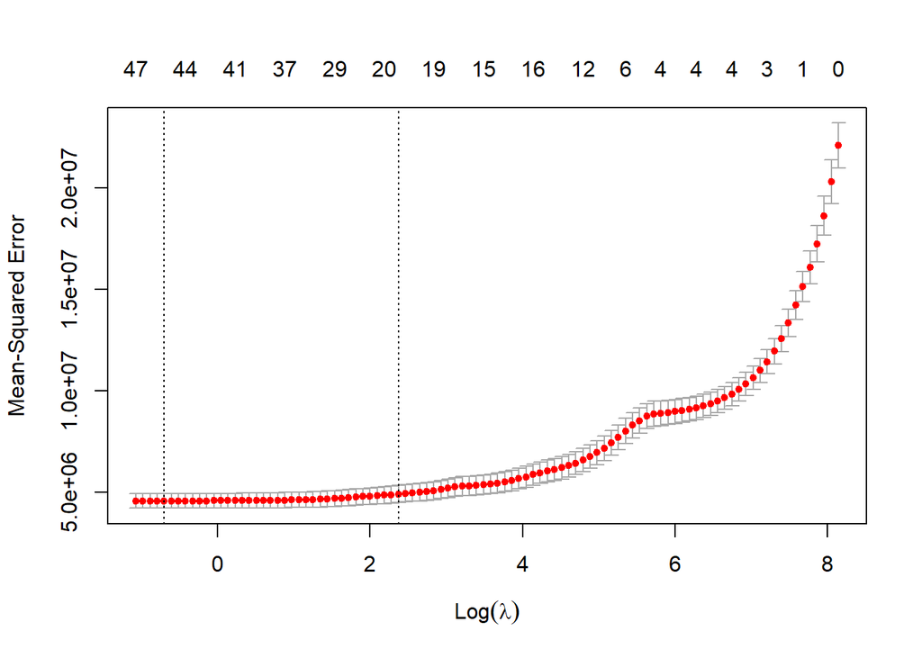

```
## [1] "Performance Summary: Absolute Percentage Errors"
##        1
##  Min.   :0.3697
##  1st Qu.:1.2599
##  Median :2.6237
##  Mean   :2.9634
##  3rd Qu.:3.7702
##  Max.   :9.8401
```

```r
penal17 <- penal_reg(feature_matrix, consumption_17)
```

```
##
## Call:  cv.glmnet(x = feature_matrix, y = consumption[8:(which(wide_format$date_wide ==      "01.11.2020") - 1)], family = "gaussian")
##
## Measure: Mean-Squared Error
##
##     Lambda Measure     SE Nonzero
## min  0.331 3672883 278740      45
## 1se  9.429 3926090 318116      23
## 49 x 1 sparse Matrix of class "dgCMatrix"
##                             1
## (Intercept)     5232.89008730
## lag_2day_hour0    -0.71464437
## lag_2day_hour1    -0.16307195
## lag_2day_hour2    -0.06095990
## lag_2day_hour3     .
## lag_2day_hour4     .
## lag_2day_hour5     0.79042264
## lag_2day_hour6     0.18569450
## lag_2day_hour7     0.08007186
## lag_2day_hour8     .
## lag_2day_hour9    -1.03528234
## lag_2day_hour10    .
## lag_2day_hour11   -0.09592568
## lag_2day_hour12    .
## lag_2day_hour13    0.70541626
## lag_2day_hour14   -0.14075010
## lag_2day_hour15    .
## lag_2day_hour16    .
## lag_2day_hour17    .
## lag_2day_hour18    0.28353940
## lag_2day_hour19    .
## lag_2day_hour20    0.10456485
## lag_2day_hour21    0.10791757
## lag_2day_hour22    .
## lag_2day_hour23    1.04593679
## lag_7day_hour0     .
## lag_7day_hour1     .
## lag_7day_hour2     .
## lag_7day_hour3     .
## lag_7day_hour4    -0.10263253
## lag_7day_hour5    -0.95175900
## lag_7day_hour6     .
## lag_7day_hour7     0.51758809
## lag_7day_hour8     0.32755186
## lag_7day_hour9     .
## lag_7day_hour10    .
## lag_7day_hour11    .
## lag_7day_hour12   -0.15569671
## lag_7day_hour13    .
## lag_7day_hour14    .
## lag_7day_hour15    .
## lag_7day_hour16    0.04964674
## lag_7day_hour17    0.73770765
## lag_7day_hour18    .
## lag_7day_hour19   -0.55277533
## lag_7day_hour20   -0.05418956
## lag_7day_hour21    .
## lag_7day_hour22    .
## lag_7day_hour23    .
```

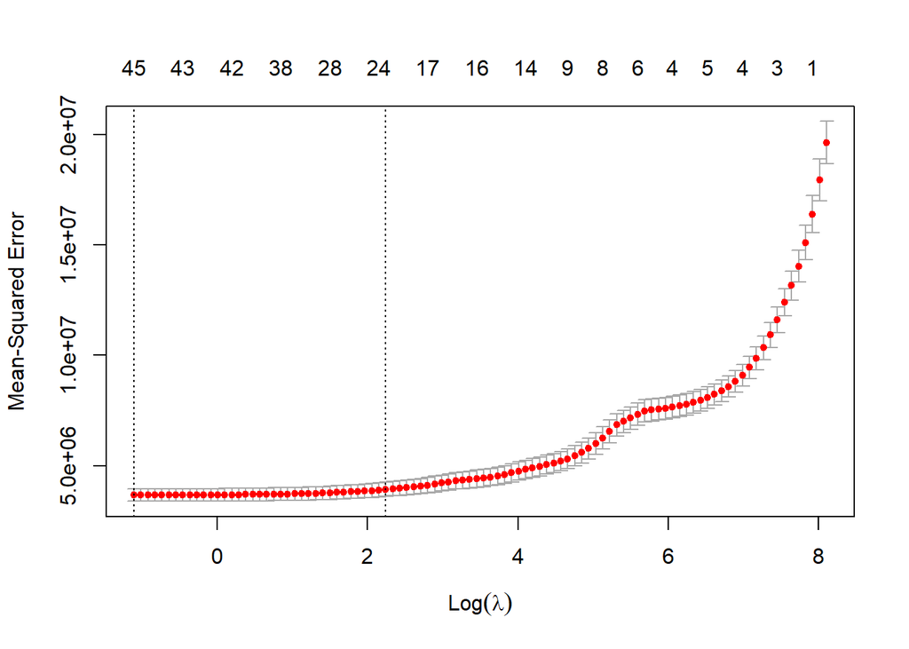

```
## [1] "Performance Summary: Absolute Percentage Errors"
##        1
##  Min.   :0.02291
##  1st Qu.:0.79614
##  Median :1.54186
##  Mean   :2.07884
##  3rd Qu.:2.28320
##  Max.   :8.43269
```

```r
penal18 <- penal_reg(feature_matrix, consumption_18)
```

```
##
## Call:  cv.glmnet(x = feature_matrix, y = consumption[8:(which(wide_format$date_wide ==      "01.11.2020") - 1)], family = "gaussian")
##
## Measure: Mean-Squared Error
##
##     Lambda Measure     SE Nonzero
## min  0.293 2582308 200760      46
## 1se  8.344 2766550 223815      24
## 49 x 1 sparse Matrix of class "dgCMatrix"
##                             1
## (Intercept)      4.904241e+03
## lag_2day_hour0  -5.750247e-01
## lag_2day_hour1  -1.145813e-01
## lag_2day_hour2  -9.319433e-02
## lag_2day_hour3   .
## lag_2day_hour4   .
## lag_2day_hour5   6.726480e-01
## lag_2day_hour6   9.994995e-02
## lag_2day_hour7   1.622585e-01
## lag_2day_hour8   .
## lag_2day_hour9  -9.699332e-01
## lag_2day_hour10  .
## lag_2day_hour11 -1.095705e-02
## lag_2day_hour12  .
## lag_2day_hour13  5.544863e-01
## lag_2day_hour14 -7.610003e-02
## lag_2day_hour15 -2.141541e-01
## lag_2day_hour16 -8.901097e-03
## lag_2day_hour17  .
## lag_2day_hour18  6.944487e-01
## lag_2day_hour19  .
## lag_2day_hour20  .
## lag_2day_hour21  5.760744e-02
## lag_2day_hour22  .
## lag_2day_hour23  8.293768e-01
## lag_7day_hour0   .
## lag_7day_hour1   .
## lag_7day_hour2   .
## lag_7day_hour3   .
## lag_7day_hour4  -4.285124e-02
## lag_7day_hour5  -8.442947e-01
## lag_7day_hour6   .
## lag_7day_hour7   4.973387e-01
## lag_7day_hour8   2.178890e-01
## lag_7day_hour9   .
## lag_7day_hour10  .
## lag_7day_hour11  .
## lag_7day_hour12 -7.167124e-02
## lag_7day_hour13  .
## lag_7day_hour14  .
## lag_7day_hour15  .
## lag_7day_hour16  1.049463e-01
## lag_7day_hour17  2.752431e-01
## lag_7day_hour18  .
## lag_7day_hour19 -1.796652e-01
## lag_7day_hour20 -5.282560e-02
## lag_7day_hour21  .
## lag_7day_hour22  .
## lag_7day_hour23  .
```

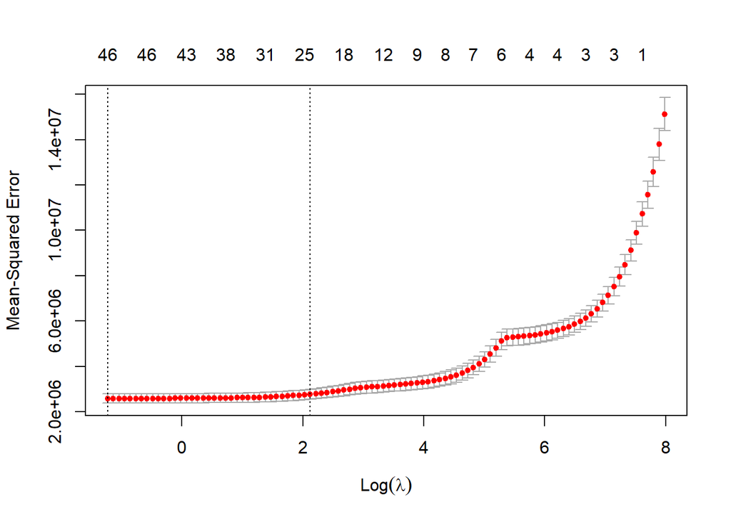

```
## [1] "Performance Summary: Absolute Percentage Errors"
##        1
##  Min.   :0.07566
##  1st Qu.:0.43759
##  Median :1.16816
##  Mean   :1.59187
##  3rd Qu.:1.94040
##  Max.   :6.32581
```

```r
penal19 <- penal_reg(feature_matrix, consumption_19)
```

```
##
## Call:  cv.glmnet(x = feature_matrix, y = consumption[8:(which(wide_format$date_wide ==      "01.11.2020") - 1)], family = "gaussian")
##
## Measure: Mean-Squared Error
##
##     Lambda Measure     SE Nonzero
## min  0.256 2094422 170886      47
## 1se  8.010 2247629 186788      22
## 49 x 1 sparse Matrix of class "dgCMatrix"
##                             1
## (Intercept)      4.185899e+03
## lag_2day_hour0  -4.791992e-01
## lag_2day_hour1  -1.874189e-01
## lag_2day_hour2   .
## lag_2day_hour3   .
## lag_2day_hour4   .
## lag_2day_hour5   5.289396e-01
## lag_2day_hour6   2.053892e-01
## lag_2day_hour7   .
## lag_2day_hour8   .
## lag_2day_hour9  -7.686033e-01
## lag_2day_hour10  .
## lag_2day_hour11 -3.469877e-02
## lag_2day_hour12  .
## lag_2day_hour13  4.674747e-01
## lag_2day_hour14 -1.397600e-01
## lag_2day_hour15 -2.072891e-02
## lag_2day_hour16 -6.767733e-02
## lag_2day_hour17  .
## lag_2day_hour18  9.129385e-02
## lag_2day_hour19  4.609424e-01
## lag_2day_hour20  1.003029e-01
## lag_2day_hour21  7.845246e-03
## lag_2day_hour22  .
## lag_2day_hour23  7.910892e-01
## lag_7day_hour0   .
## lag_7day_hour1   .
## lag_7day_hour2   .
## lag_7day_hour3   .
## lag_7day_hour4  -1.813842e-01
## lag_7day_hour5  -5.790049e-01
## lag_7day_hour6   .
## lag_7day_hour7   4.774969e-01
## lag_7day_hour8   1.551292e-01
## lag_7day_hour9   .
## lag_7day_hour10  .
## lag_7day_hour11 -5.948512e-02
## lag_7day_hour12  .
## lag_7day_hour13  .
## lag_7day_hour14  .
## lag_7day_hour15  .
## lag_7day_hour16  1.499560e-01
## lag_7day_hour17  1.858485e-02
## lag_7day_hour18  .
## lag_7day_hour19  .
## lag_7day_hour20  .
## lag_7day_hour21  .
## lag_7day_hour22  .
## lag_7day_hour23  .
```

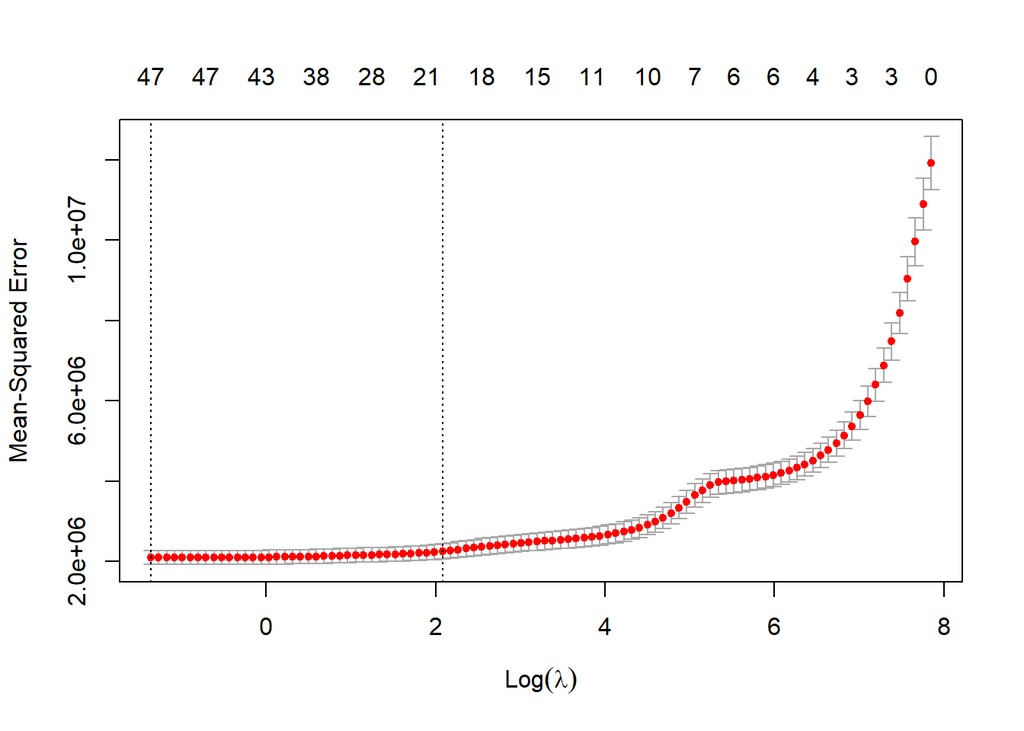

```
## [1] "Performance Summary: Absolute Percentage Errors"
##        1
##  Min.   :0.01508
##  1st Qu.:0.40117
##  Median :0.98404
##  Mean   :1.43620
##  3rd Qu.:1.84065
##  Max.   :5.67831
```

```r
penal20 <- penal_reg(feature_matrix, consumption_20)
```

```
##
## Call:  cv.glmnet(x = feature_matrix, y = consumption[8:(which(wide_format$date_wide ==      "01.11.2020") - 1)], family = "gaussian")
##
## Measure: Mean-Squared Error
##
##     Lambda Measure     SE Nonzero
## min  0.260 1851846 146786      45
## 1se  6.745 1991462 162361      21
## 49 x 1 sparse Matrix of class "dgCMatrix"
##                             1
## (Intercept)      3.844479e+03
## lag_2day_hour0  -7.115753e-02
## lag_2day_hour1  -2.507341e-01
## lag_2day_hour2  -4.036017e-01
## lag_2day_hour3   .
## lag_2day_hour4   .
## lag_2day_hour5   7.279994e-01
## lag_2day_hour6   .
## lag_2day_hour7   .
## lag_2day_hour8   .
## lag_2day_hour9  -6.677742e-01
## lag_2day_hour10  .
## lag_2day_hour11  .
## lag_2day_hour12  .
## lag_2day_hour13  3.496726e-01
## lag_2day_hour14 -9.478237e-02
## lag_2day_hour15  .
## lag_2day_hour16 -8.043937e-02
## lag_2day_hour17  .
## lag_2day_hour18  .
## lag_2day_hour19 -2.600818e-02
## lag_2day_hour20  5.472189e-01
## lag_2day_hour21  1.935429e-01
## lag_2day_hour22  .
## lag_2day_hour23  6.846897e-01
## lag_7day_hour0   .
## lag_7day_hour1   .
## lag_7day_hour2   .
## lag_7day_hour3   .
## lag_7day_hour4  -2.390446e-02
## lag_7day_hour5  -6.682930e-01
## lag_7day_hour6   .
## lag_7day_hour7   3.760770e-01
## lag_7day_hour8   2.142838e-01
## lag_7day_hour9   .
## lag_7day_hour10  .
## lag_7day_hour11 -1.181538e-01
## lag_7day_hour12  .
## lag_7day_hour13  .
## lag_7day_hour14  .
## lag_7day_hour15  2.309511e-03
## lag_7day_hour16  1.724144e-01
## lag_7day_hour17  .
## lag_7day_hour18  .
## lag_7day_hour19 -7.888922e-02
## lag_7day_hour20  .
## lag_7day_hour21  1.187003e-01
## lag_7day_hour22  .
## lag_7day_hour23  .
```

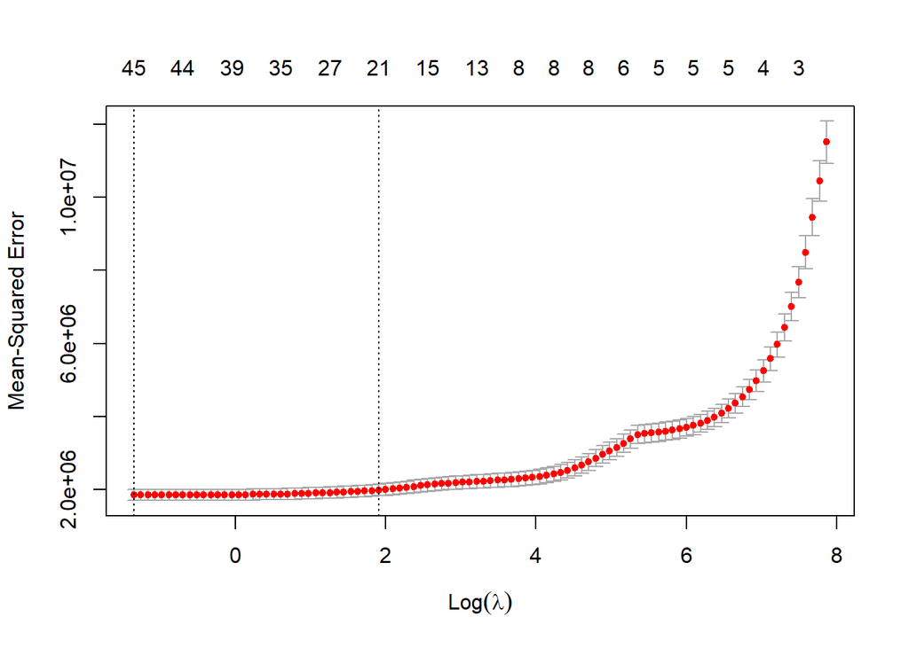

```
## [1] "Performance Summary: Absolute Percentage Errors"
##        1
##  Min.   :0.01021
##  1st Qu.:0.62654
##  Median :0.98438
##  Mean   :1.56238
##  3rd Qu.:2.12570
##  Max.   :6.10131
```

```r
penal21 <- penal_reg(feature_matrix, consumption_21)
```

```
##
## Call:  cv.glmnet(x = feature_matrix, y = consumption[8:(which(wide_format$date_wide ==      "01.11.2020") - 1)], family = "gaussian")
##
## Measure: Mean-Squared Error
##
##     Lambda Measure     SE Nonzero
## min  0.280 1747010 148062      47
## 1se  6.611 1882935 162691      21
## 49 x 1 sparse Matrix of class "dgCMatrix"
##                             1
## (Intercept)      4.325672e+03
## lag_2day_hour0  -4.831280e-02
## lag_2day_hour1  -3.051485e-01
## lag_2day_hour2  -1.721855e-01
## lag_2day_hour3   .
## lag_2day_hour4   .
## lag_2day_hour5   4.300538e-01
## lag_2day_hour6   7.447233e-02
## lag_2day_hour7   4.183701e-03
## lag_2day_hour8   .
## lag_2day_hour9  -6.237736e-01
## lag_2day_hour10  .
## lag_2day_hour11  .
## lag_2day_hour12  .
## lag_2day_hour13  2.629953e-01
## lag_2day_hour14 -5.983007e-02
## lag_2day_hour15  .
## lag_2day_hour16 -4.492503e-02
## lag_2day_hour17  .
## lag_2day_hour18  .
## lag_2day_hour19 -2.207189e-02
## lag_2day_hour20  4.050488e-02
## lag_2day_hour21  6.575568e-01
## lag_2day_hour22  .
## lag_2day_hour23  6.924456e-01
## lag_7day_hour0   .
## lag_7day_hour1   .
## lag_7day_hour2   .
## lag_7day_hour3   .
## lag_7day_hour4   .
## lag_7day_hour5  -7.112940e-01
## lag_7day_hour6   .
## lag_7day_hour7   3.893786e-01
## lag_7day_hour8   2.044746e-01
## lag_7day_hour9   .
## lag_7day_hour10  .
## lag_7day_hour11 -1.064575e-01
## lag_7day_hour12  .
## lag_7day_hour13  .
## lag_7day_hour14  .
## lag_7day_hour15  .
## lag_7day_hour16  1.655560e-01
## lag_7day_hour17  .
## lag_7day_hour18  .
## lag_7day_hour19 -1.842035e-01
## lag_7day_hour20  .
## lag_7day_hour21  2.241503e-01
## lag_7day_hour22  .
## lag_7day_hour23  .
```

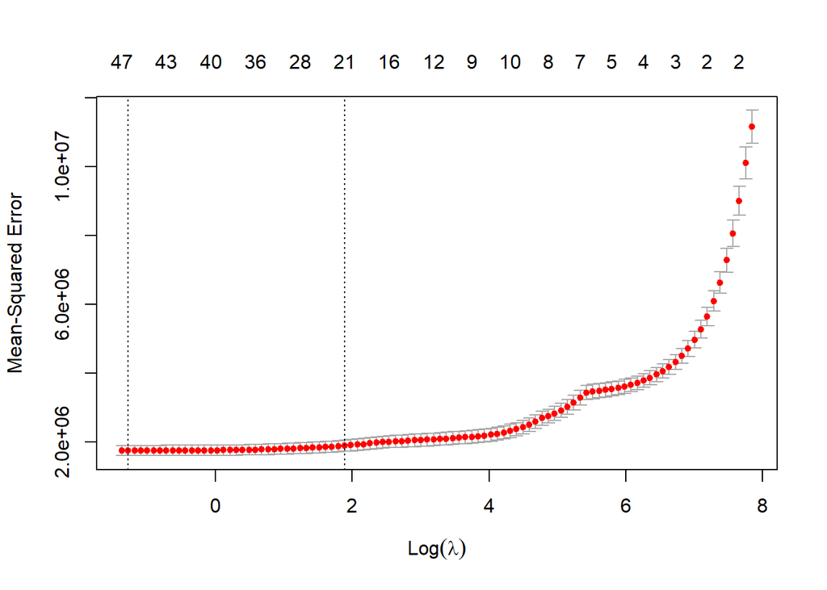

```
## [1] "Performance Summary: Absolute Percentage Errors"
##        1
##  Min.   :0.02594
##  1st Qu.:0.50702
##  Median :1.38975
##  Mean   :1.58153
##  3rd Qu.:2.03657
##  Max.   :5.55501
```

```r
penal22 <- penal_reg(feature_matrix, consumption_22)
```

```
##
## Call:  cv.glmnet(x = feature_matrix, y = consumption[8:(which(wide_format$date_wide ==      "01.11.2020") - 1)], family = "gaussian")
##
## Measure: Mean-Squared Error
##
##     Lambda Measure     SE Nonzero
## min  0.240 1735605 160800      45
## 1se  8.229 1890238 176030      20
## 49 x 1 sparse Matrix of class "dgCMatrix"
##                             1
## (Intercept)      5.516271e+03
## lag_2day_hour0  -3.099477e-02
## lag_2day_hour1  -2.069830e-01
## lag_2day_hour2  -1.420586e-01
## lag_2day_hour3   .
## lag_2day_hour4   .
## lag_2day_hour5   3.511758e-01
## lag_2day_hour6   .
## lag_2day_hour7   .
## lag_2day_hour8  -3.991113e-03
## lag_2day_hour9  -5.523579e-01
## lag_2day_hour10  .
## lag_2day_hour11  .
## lag_2day_hour12  .
## lag_2day_hour13  1.592972e-01
## lag_2day_hour14  .
## lag_2day_hour15  .
## lag_2day_hour16 -1.123911e-03
## lag_2day_hour17  .
## lag_2day_hour18  .
## lag_2day_hour19  .
## lag_2day_hour20  .
## lag_2day_hour21  3.770667e-01
## lag_2day_hour22  .
## lag_2day_hour23  8.986691e-01
## lag_7day_hour0   .
## lag_7day_hour1   .
## lag_7day_hour2  -7.083800e-03
## lag_7day_hour3   .
## lag_7day_hour4  -9.379090e-02
## lag_7day_hour5  -5.609665e-01
## lag_7day_hour6   .
## lag_7day_hour7   3.479066e-01
## lag_7day_hour8   1.829080e-01
## lag_7day_hour9   .
## lag_7day_hour10  .
## lag_7day_hour11  .
## lag_7day_hour12 -3.599814e-02
## lag_7day_hour13  .
## lag_7day_hour14  .
## lag_7day_hour15  .
## lag_7day_hour16  1.541579e-01
## lag_7day_hour17  .
## lag_7day_hour18  .
## lag_7day_hour19 -2.077215e-01
## lag_7day_hour20  .
## lag_7day_hour21  .
## lag_7day_hour22  8.319958e-02
## lag_7day_hour23  1.121243e-01
```

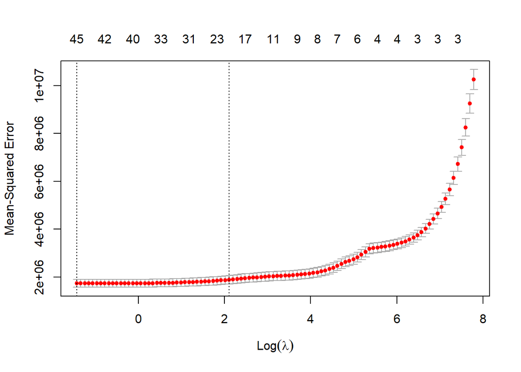

```
## [1] "Performance Summary: Absolute Percentage Errors"
##        1
##  Min.   :0.00057
##  1st Qu.:0.60795
##  Median :1.01897
##  Mean   :1.48620
##  3rd Qu.:2.09902
##  Max.   :5.23091
```

```r
penal23 <- penal_reg(feature_matrix, consumption_23)
```

```
##
## Call:  cv.glmnet(x = feature_matrix, y = consumption[8:(which(wide_format$date_wide ==      "01.11.2020") - 1)], family = "gaussian")
##
## Measure: Mean-Squared Error
##
##     Lambda Measure     SE Nonzero
## min  0.413 1600865 142477      43
## 1se  7.385 1730783 152642      21
## 49 x 1 sparse Matrix of class "dgCMatrix"
##                             1
## (Intercept)      4.337630e+03
## lag_2day_hour0  -6.747406e-02
## lag_2day_hour1  -1.888658e-01
## lag_2day_hour2  -2.814876e-02
## lag_2day_hour3   .
## lag_2day_hour4   .
## lag_2day_hour5   2.274123e-01
## lag_2day_hour6   2.891604e-02
## lag_2day_hour7   .
## lag_2day_hour8   .
## lag_2day_hour9  -5.274439e-01
## lag_2day_hour10  .
## lag_2day_hour11  .
## lag_2day_hour12  .
## lag_2day_hour13  1.644596e-01
## lag_2day_hour14 -1.859499e-02
## lag_2day_hour15  .
## lag_2day_hour16 -1.414644e-03
## lag_2day_hour17  .
## lag_2day_hour18  .
## lag_2day_hour19  .
## lag_2day_hour20  .
## lag_2day_hour21  3.021096e-01
## lag_2day_hour22  .
## lag_2day_hour23  9.323478e-01
## lag_7day_hour0   .
## lag_7day_hour1   .
## lag_7day_hour2   .
## lag_7day_hour3   .
## lag_7day_hour4  -1.114513e-01
## lag_7day_hour5  -5.561970e-01
## lag_7day_hour6   .
## lag_7day_hour7   4.269343e-01
## lag_7day_hour8   1.123144e-01
## lag_7day_hour9   .
## lag_7day_hour10  .
## lag_7day_hour11 -1.105717e-04
## lag_7day_hour12 -2.127503e-02
## lag_7day_hour13  .
## lag_7day_hour14  .
## lag_7day_hour15  .
## lag_7day_hour16  1.130654e-01
## lag_7day_hour17  1.935601e-02
## lag_7day_hour18  .
## lag_7day_hour19 -2.047100e-01
## lag_7day_hour20  .
## lag_7day_hour21  .
## lag_7day_hour22  .
## lag_7day_hour23  2.299199e-01
```

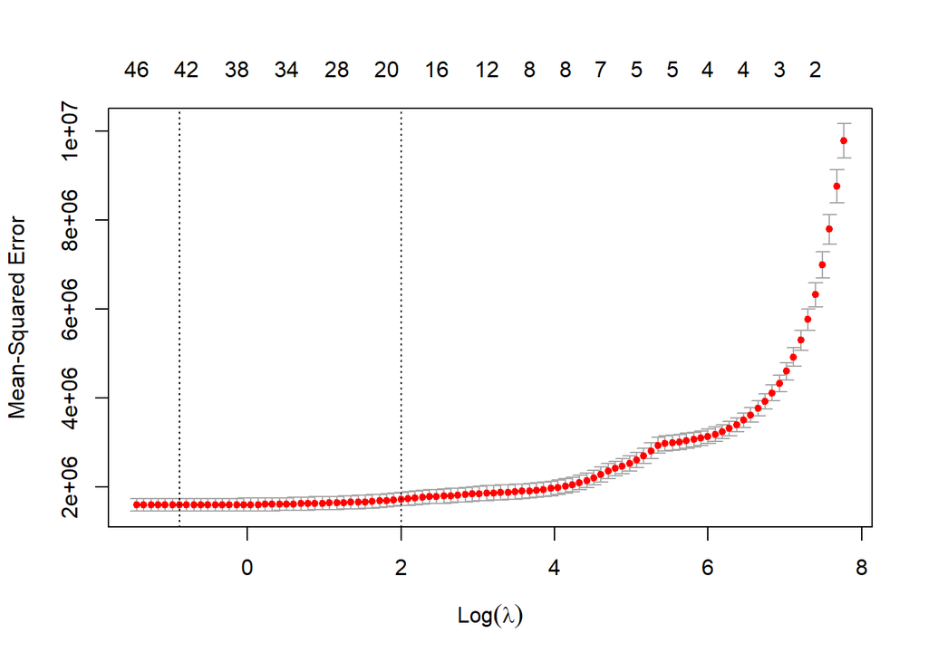

```
## [1] "Performance Summary: Absolute Percentage Errors"
##        1
##  Min.   :0.2176
##  1st Qu.:0.6696
##  Median :1.2730
##  Mean   :1.7805
##  3rd Qu.:2.5311
##  Max.   :5.5687
```

```r
#Overall Performance
perf_penal <- c(penal0, penal1, penal2, penal3, penal4, penal5, penal6, penal7,
                penal8, penal9, penal10, penal11, penal12, penal13, penal14, penal15,
                penal16, penal17, penal18, penal19, penal20, penal21, penal22, penal23)
print('Performance Summary: Absolute Percentage Errors')
```

```
## [1] "Performance Summary: Absolute Percentage Errors"
```

```r
summary(perf_penal)
```

```
##     Min.  1st Qu.   Median     Mean  3rd Qu.     Max.
##  0.00057  0.74974  1.70456  2.47605  3.35157 14.41741
```

According to the penalized regression applications for each hour, in general, the lambda values vary between 5 to 15 and number of features used are between 15 and 25. In terms of overall performance, the penalized regression performs better than naive and linear regression models in terms of MAPE. It is also noticed that similar to linear regression, penalized regression’s performance decreases towards the mid-day hours.

# PART F

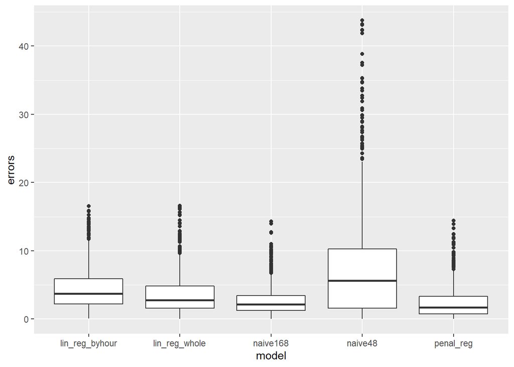

```r
model <- c(rep("naive48", 576), rep("naive168", 576), rep("lin_reg_whole", 576), rep("lin_reg_byhour", 31*24), rep("penal_reg", 31*24))

errors <- c(naive48, naive168, linreg_whole,
                  linreg0, linreg1, linreg2, linreg3, linreg4, linreg5, linreg6, linreg7,
                  linreg8, linreg9, linreg10, linreg11, linreg12, linreg13, linreg14, linreg15,
                  linreg16, linreg17, linreg18, linreg19, linreg20, linreg21, linreg22, linreg23,
                  penal0, penal1, penal2, penal3, penal4, penal5, penal6, penal7,
                  penal8, penal9, penal10, penal11, penal12, penal13, penal14, penal15,
                  penal16, penal17, penal18, penal19, penal20, penal21, penal22, penal23)

performance_data <- data.frame(model, errors)
ggplot(performance_data, aes(x=model, y=errors))+geom_boxplot()
```

When the boxplots are analyzed, it is observed that penalized regression approach works best for forecasting the electricity consumption data. The reason of this outcome mainly is the fact that the data includes high correlation between features and penalized regression copes with such autocorrelated data well by penalizing the coefficients of features. Since linear regression is affected more from the correlated features it could not perform better than naive model with 168 hour lag, however, their MAPE values still were a lot lower than the naive model with lag 48 hours.